# Lectures on the design and analysis of experiments

### 4.15.5 Important Examples : Collider

But controlling can also cause problems. In fact conditioning on a temporally pre-treatment variable could cause problems. Who’d have thunk? Here is an example from Pearl (2005):

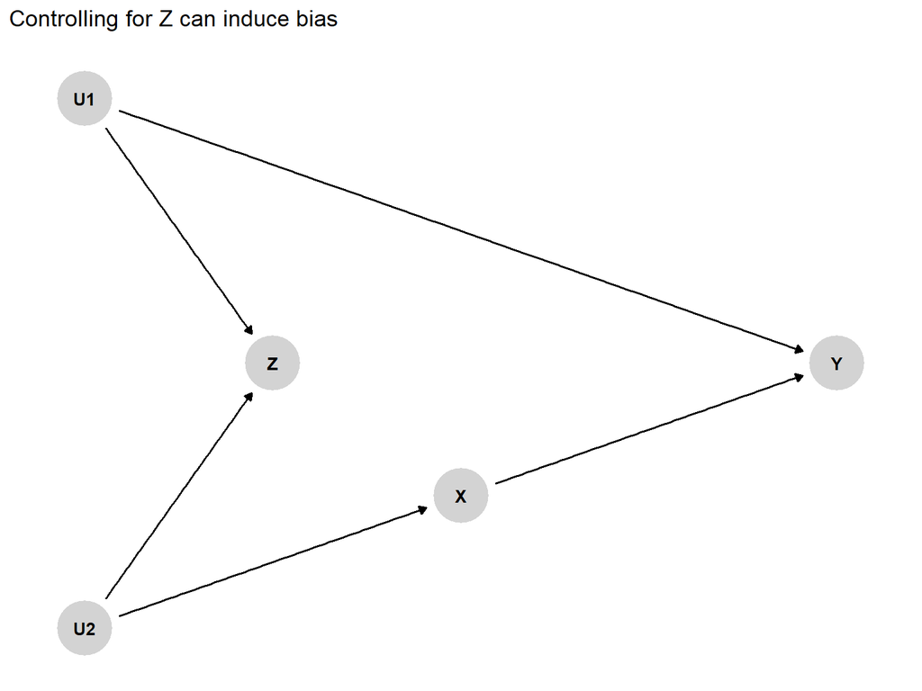

### 4.15.6 Illustration of identification failure from conditioning on a collider

```r
U1 <- rnorm(10000);  U2 <- rnorm(10000)
Z  <- U1+U2
X  <- U2 + rnorm(10000)/2
Y  <- U1*2 + X

lm_robust(Y ~ X) |> tidy() |> kable(digits = 2)
```

| term | estimate | std.error | statistic | p.value | conf.low | conf.high | df | outcome |
| --- | --- | --- | --- | --- | --- | --- | --- | --- |
| (Intercept) | -0.02 | 0.02 | -1.21 | 0.23 | -0.06 | 0.01 | 9998 | Y |
| X | 1.02 | 0.02 | 56.52 | 0.00 | 0.98 | 1.05 | 9998 | Y |

```r
lm_robust(Y ~ X + Z) |> tidy() |> kable(digits = 2)
```

| term | estimate | std.error | statistic | p.value | conf.low | conf.high | df | outcome |
| --- | --- | --- | --- | --- | --- | --- | --- | --- |
| (Intercept) | -0.01 | 0.01 | -1.13 | 0.26 | -0.03 | 0.01 | 9997 | Y |
| X | -0.34 | 0.01 | -34.98 | 0.00 | -0.36 | -0.32 | 9997 | Y |
| Z | 1.67 | 0.01 | 220.37 | 0.00 | 1.65 | 1.68 | 9997 | Y |

### 4.15.7 Let’s look at that in dagitty

```r
g <- dagitty("dag{U1 -> Z  ; U1 -> y ; U2 -> Z ; U2 -> x  -> y}")
adjustmentSets(g, exposure = "x", outcome = "y")
```

```
 {}
```

```r
isAdjustmentSet(g, "Z", exposure = "x", outcome = "y")
```

```
[1] FALSE
```

```r
isAdjustmentSet(g, NULL, exposure = "x", outcome = "y")
```

```
[1] TRUE
```

Which means, no need to condition on anything.

### 4.15.8 Collider & Confounder

A bind: from Pearl 1995.

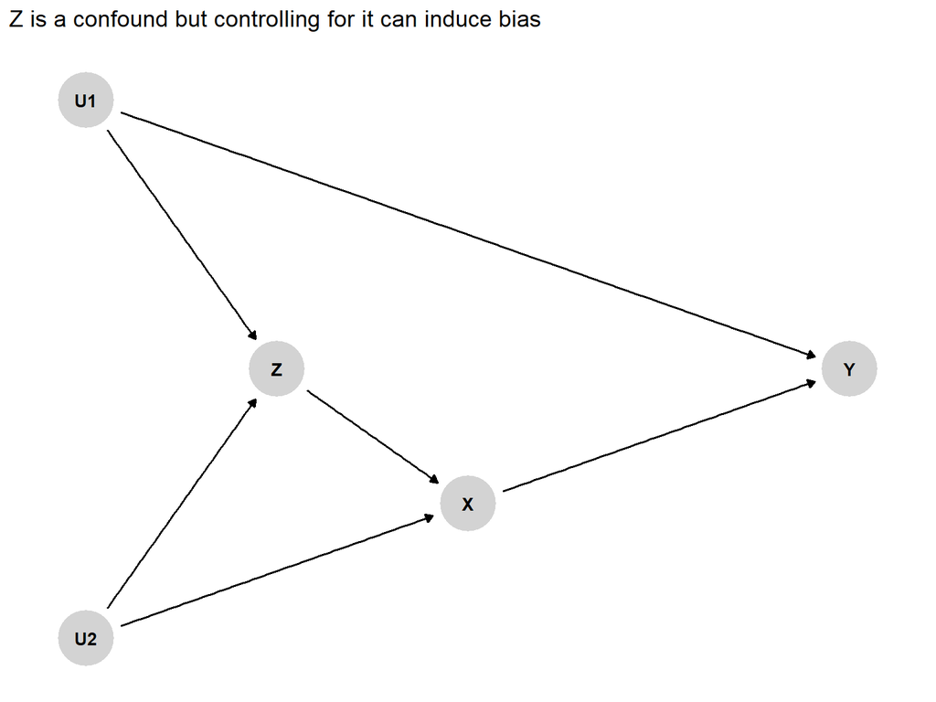

For a solution for a class of related problems see Robins, Hernan, and Brumback (2000)

### 4.15.9 Let’s look at that in dagitty

```r
g <- dagitty("dag{U1 -> Z  ; U1 -> y ;
             U2 -> Z ; U2 -> x  -> y;
             Z -> x}")
adjustmentSets(g, exposure = "x", outcome = "y")
```

```
{ U1 }
{ U2, Z }
```

```r
isAdjustmentSet(g, "Z", exposure = "x", outcome = "y")
```

```
[1] FALSE
```

```r
isAdjustmentSet(g, NULL, exposure = "x", outcome = "y")
```

```
[1] FALSE
```

### 4.15.10 Collider & Confounder

So we cannot *identify* the effect here. But can we still learn about it?

# 5 Answer strategies

## 5.1 Outline

- Simple estimates from experimental data
- Weighting, blocking
- Design-based variance estimates
- Design-based $p$ values
- Reporting

See topics for *Controls and doubly robust estimation*

### 5.1.1 ATE: DIM

Unbiased estimates of the (sample) average treatment effect can be estimated (**whether or not there imbalance on covariates**) using:

$$\widehat{ATE} = \frac{1}{n_T}\sum_TY_i - \frac{1}{n_C}\sum_CY_i,$$

### 5.1.2 ATE: DIM in practice

```r
df <- fabricatr::fabricate(N = 100, Z = rep(0:1, N/2), Y = rnorm(N) + Z)

# by hand
df |>
  summarize(Y1 = mean(Y[Z==1]),
            Y0 = mean(Y[Z==0]),
            diff = Y1 - Y0) |> kable(digits = 2)
```

| Y1 | Y0 | diff |
| --- | --- | --- |
| 1.07 | -0.28 | 1.35 |

```r
# with estimatr
estimatr::difference_in_means(Y ~ Z, data = df) |>
  tidy() |> kable(digits = 2)
```

| term | estimate | std.error | statistic | p.value | conf.low | conf.high | df | outcome |
| --- | --- | --- | --- | --- | --- | --- | --- | --- |
| Z | 1.35 | 0.17 | 7.94 | 0 | 1.01 | 1.68 | 97.98 | Y |

### 5.1.3 ATE: DIM in practice

We can also do this with regression:

```r
estimatr::lm_robust(Y ~ Z, data = df) |>
  tidy() |> kable(digits = 2)
```

| term | estimate | std.error | statistic | p.value | conf.low | conf.high | df | outcome |
| --- | --- | --- | --- | --- | --- | --- | --- | --- |
| (Intercept) | -0.28 | 0.12 | -2.33 | 0.02 | -0.51 | -0.04 | 98 | Y |
| Z | 1.35 | 0.17 | 7.94 | 0.00 | 1.01 | 1.68 | 98 | Y |

See Freedman (2008) on why regression is fine here

### 5.1.4 ATE: Blocks

Say now different strata or blocks $\mathcal{S}$ had different *assignment probabilities*. Then you could estimate:

$$\widehat{ATE} = \sum_{S\in \mathcal{S}}\frac{n_{S}}{n}
\left(\frac{1}{n_{S1}}\sum_{S\cap T}y_i - \frac{1}{n_{S0}}\sum_{S\cap C}y_i \right)$$

**Note**: you cannot just ignore the blocks because assignment is no longer independent of potential outcomes: you might be sampling units with different potential outcomes with different probabilities.

However, the formula above works fine because selecting is random *conditional* on blocks.

### 5.1.5 ATE: Blocks

As a DAG this is just classic confounding:

```r
make_model("Block -> Z ->Y <- Block") |>
  plot(x_coord = c(2,1,3), y_coord = c(2, 1, 1))
```

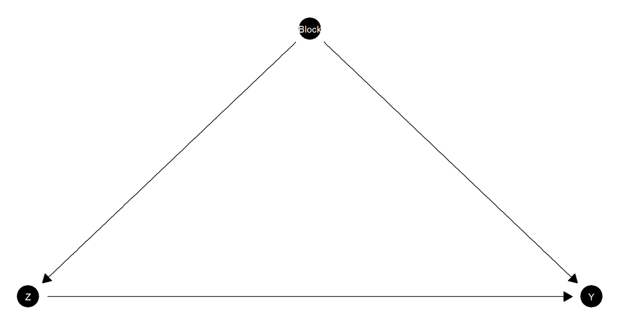

### 5.1.6 ATE: Blocks in practice

Data with heterogeneous assignments:

```r
df <- fabricatr::fabricate(
  N = 500, X = rep(0:1, N/2),
  prob = .2 + .3*X,
  Z = rbinom(N, 1, prob),
  ip = 1/(Z*prob + (1-Z)*(1-prob)), # discuss
  Y = rnorm(N) + Z*X)
```

True effect is 0.5, but:

```r
estimatr::difference_in_means(Y ~ Z, data = df) |>
  tidy() |> kable(digits = 2)
```

| term | estimate | std.error | statistic | p.value | conf.low | conf.high | df | outcome |
| --- | --- | --- | --- | --- | --- | --- | --- | --- |
| Z | 0.9 | 0.1 | 9.32 | 0 | 0.71 | 1.09 | 377.93 | Y |

### 5.1.7 ATE: Blocks in practice

Averaging over effects in blocks

```r
# by hand
estimates <-
  df |>
  group_by(X) |>
  summarize(Y1 = mean(Y[Z==1]),
            Y0 = mean(Y[Z==0]),
            diff = Y1 - Y0,
            W = n())

estimates$diff |> weighted.mean(estimates$W)
```

```
[1] 0.7236939
```

```r
# with estimatr
estimatr::difference_in_means(Y ~ Z, blocks = X, data = df) |>
  tidy() |> kable(digits = 2)
```

| term | estimate | std.error | statistic | p.value | conf.low | conf.high | df | outcome |
| --- | --- | --- | --- | --- | --- | --- | --- | --- |
| Z | 0.72 | 0.11 | 6.66 | 0 | 0.51 | 0.94 | 496 | Y |

### 5.1.8 ATE with IPW

This also corresponds to the difference in the weighted average of treatment outcomes (with weights given by the inverse of the probability that each unit is assigned to treatment) and control outcomes (with weights given by the inverse of the probability that each unit is assigned to control).

- The average difference in means estimator is the same as what you would get if you weighted inversely by shares of units in different conditions inside blocks.

### 5.1.9 ATE with IPW in practice

```r
# by hand
df |>
  summarize(Y1 = weighted.mean(Y[Z==1], ip[Z==1]),
            Y0 = weighted.mean(Y[Z==0],  ip[Z==0]), # note !
            diff = Y1 - Y0)|>
  kable(digits = 2)
```

| Y1 | Y0 | diff |
| --- | --- | --- |
| 0.59 | -0.15 | 0.74 |

```r
# with estimatr
estimatr::difference_in_means(Y ~ Z, weights = ip, data = df) |>
  tidy() |> kable(digits = 2)
```

| term | estimate | std.error | statistic | p.value | conf.low | conf.high | df | outcome |
| --- | --- | --- | --- | --- | --- | --- | --- | --- |
| Z | 0.74 | 0.11 | 6.65 | 0 | 0.52 | 0.96 | 498 | Y |

### 5.1.10 ATE with IPW

- But **inverse propensity weighting** is a more general principle, which can be used even if you do not have blocks.
- The intuition for it comes straight from **sampling weights** — you weight up in order to recover an unbiased estimate of the potential outcomes for all units, whether or not they are assigned to treatment.
- With sampling weights however you can include units even if their weight was 1. *Why can you not include these units when doing inverse propensity weighting?*

### 5.1.11 Illustration: Estimating treatment effects with terrible treatment assignments: Fixer

Say you made a mess and used a randomization that was correlated with some variable, $U$. For example:

- The randomization is done in a way that introduces a correlation between Treatment Assignment and Potential Outcomes
- Then possibly, even though there is no true causal effect, we naively estimate a large one — enormous bias
- However since we know the assignment procedure we can **fully** correct for the bias

### 5.1.12 Illustration: Estimating treatment effects with terrible treatment assignments: Fixer

- In the next example, we do this using “**inverse propensity score weighting**.”
- This is exactly analogous to standard survey weighting — since we selected different units for treatment with different probabilities, we weight them differently to recover the average outcome among treated units (same for control).

### 5.1.13 Basic randomization: Fixer

Bad assignment, some randomization process you can’t understand (but can replicate) that results in unequal probabilities.

```r
N <- 400
U <- runif(N, .1, .9)

 design <-
   declare_model(N = N,
                 Y_Z_0 = U + rnorm(N, 0, .1),
                 Y_Z_1 = U + rnorm(N, 0, .1),
                 Z = rbinom(N, 1, U)) +
  declare_measurement(Y = reveal_outcomes(Y ~ Z)) +
  declare_inquiry(ATE = mean(Y_Z_1 - Y_Z_0)) +
  declare_estimator(Y ~ Z, label = "naive")
```

### 5.1.14 Basic randomization: Fixer

Results is a sampling distribution not centered on the true effect (0)

```r
diagnosis <- diagnose_design(design)
```

```r
diagnosis$simulations_df |>
  ggplot(aes(estimate)) + geom_histogram() + facet_grid(~estimator) +
  geom_vline(xintercept = 0, color = "red")
```

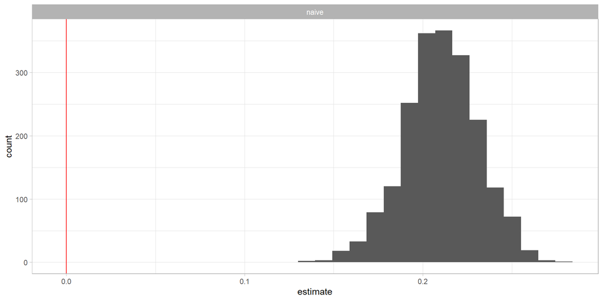

### 5.1.15 A fix

To fix you can estimate the assignment probabilities by replicating the assignment many times:

```r
probs <- replicate(1000, design |> draw_data() |> pull(Z)) |> apply(1, mean)
```

and then use these assignment probabilities in your estimator

```r
design_2 <-
  design +
  declare_measurement(weights = Z/probs + (1-Z)/(1-probs)) +
  declare_estimator(Y ~ Z, weights = weights, label = "smart")
```

### 5.1.16 Basic randomization: Fixer

Implied weights

```r
draw_data(design_2) |>
  ggplot(aes(probs, weights, color = factor(Z))) +
  geom_point()
```

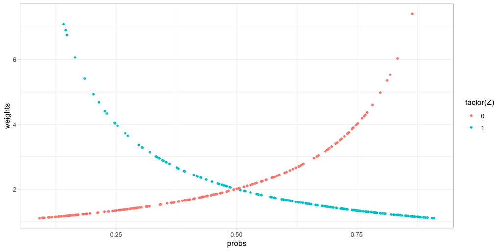

### 5.1.17 Basic randomization: Fixer

Improved results

```r
diagnosis <- diagnose_design(design_2)
```

```r
diagnosis$simulations_df |>
  ggplot(aes(estimate)) + geom_histogram() + facet_grid(estimator~.)+
  geom_vline(xintercept = 0, color = "red")
```

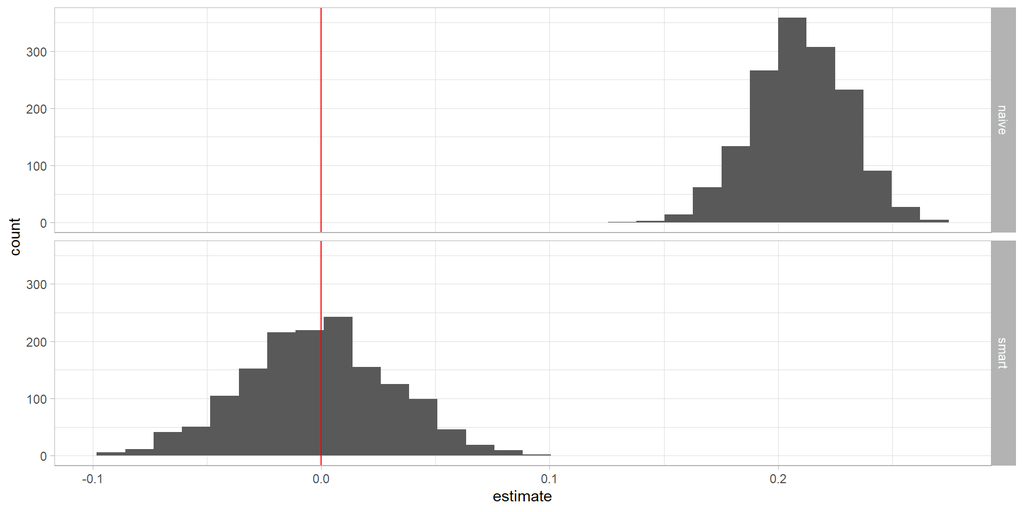

### 5.1.18 IPW with one unit!

This example is surprising but it helps you see the logic of why inverse weighting gets unbiased estimates (and why that might not guarantee a reasonable answer)

Imagine there is one unit with potential outcomes $Y(1) = 2, Y(0) = 1$. So the unit level treatment effect is 1.

You toss a coin.

- If you assign to treatment you estimate: $\hat\tau = \frac{2}{0.5} = 4$
- If you assign to control you estimate: $\hat\tau = -\frac{1}{0.5} = -2$

Great on average but *always* lousy

### 5.1.19 Generalization: why IPW works

- Say a given unit is assigned to treatment with probability $\pi_i$
- We estimate the average $Y(1)$ using

$$\hat{\overline{Y_1}} = \frac{1}n\left(\sum_i \frac{Z_iY_i(1)}{\pi_i}\right)$$
With independent assignment the expected value of $\hat{\overline{Y_1}}$ is just:

$$\mathbb{E}[\hat{\overline{Y_1}}] =\frac1n\left( \left(\pi_1 \frac{1\times Y_1(1)}{\pi_1} + (1-\pi_1) \frac{0\times Y_1(1)}{\pi_1}\right) + \left(\pi_2 \frac{1\times Y_2(1)}{\pi_2} + (1-\pi_2) \frac{0\times Y_1(1)}{\pi_2}\right) + \dots\right)$$

$$\mathbb{E}[\hat{\overline{Y_1}}] =\frac1n\left( Y_1(1) + Y_2(1) + \dots\right) = \overline{Y_1}$$

and similarly for $\mathbb{E}[\hat{\overline{Y_0}}]$ and so using linearity of expectations:

$$\mathbb{E}[\widehat{\overline{Y_1 - Y_0}}] = \overline{Y_1 - Y_0}$$

### 5.1.20 Generalization: why IPW works

- Note we needed $\pi_i >0$ and also $\pi_i <1$ everywhere. Why?
- We used independence here; sampling theory is used to show similar results for e.g. complete randomization
- For blocked randomization this is easy to see

## 5.2 Design-based Estimation of Variance

*Lets talk about “inference”*

### 5.2.1 Var(ATE)

- Recall that the treatment effect is gotten by taking a sample of outcomes under treatment and comparing them to a sample of outcomes under control
- Say that there is no “error”
- Why would this procedure produce uncertainty?

### 5.2.2 Var(ATE)

- Why would this procedure produce uncertainty?
- The uncertainty comes from being uncertain about the average outcome under control from observations of the control units, and from being uncertain about the average outcome under treatment from observation of the treated units
- In other words, it comes from the variance in the treatment outcomes and variance in the control outcomes (and not, for example, from variance in the treatment effect)

### 5.2.3 Var(ATE)

- In classical statistics we characterize our uncertainty over an estimate using an estimate of variance of the sampling distribution of the estimator.
- Key idea is we want to be able to say: how likely are we to have gotten such an estimate if the distribution of estimates associated with our design looked a given way.
- More specifically we want to estimate “standard error” or the “standard deviation of the sampling distribution”

(See [Woolridge (2023)](https://www.sciencedirect.com/science/article/pii/S0304407623002336) where the standard error is understood as the “*estimate* of the standard deviation of the sampling distribution”)

### 5.2.4 Variance and standard errors

Given:

- $\hat\tau$ is an estimate for $\tau$
- $\overline{x}$ is the average values of $x$

The variance of the estimator of $n$ repeated ‘runs’ of a design is: $Var(\hat{\tau}) = \frac{1}n\sum_i(\hat\tau_i - \overline{\hat\tau_i})^2$

And the standard error is:

$se(\hat{\tau}) = \sqrt{\frac{1}n\sum_i(\hat\tau_i - \overline{\hat\tau_i})^2}$

### 5.2.5 Variance and standard errors

If we have a good measure for the *shape* of the sampling distribution we can start to make statements of the form:

- What are the chances that an estimate would be this large or larger?

If the sampling distribution is roughly normal, as it may be with large samples, then we can use procedures such as: “there is a 5% probability that an estimate would be more than 1.96 standard errors away from the mean of the sampling distribution”

### 5.2.6 Var(ATE)

- **Key idea**: You can estimate variance straight from the data, given knowledge of the **assignment process** and assuming well defined potential outcomes?
- Recall in general $Var(x) = \frac{1}n\sum_i(x_i - \overline{x})^2$. here the $x_i$s are the treatment effect estimates we might get under different random assignments, the $n$ is number of different assignments (assumed here all equally likely, but otherwise we can weight) and $\overline{x}$ is the truth.
- For intuition imagine we have just two units $A$, $B$, with potential outcomes $A_1$, $A_0$, $B_1$, $B_0$.
- When there are two units with outcomes $x_1, x_2$, the variance simplifies like this:

$$Var(x) = \frac{1}2\left(x_1 - \frac{x_1 + x_2}{2}\right)^2 + \frac{1}2\left(x_2 - \frac{x_1 + x_2}{2}\right)^2 = \left(\frac{x_1 - x_2}{2}\right)^2$$

### 5.2.7 Var(ATE)

In the two unit case the two possible treatment estimates are: $\hat{\tau}_1=A_1 - B_0$ and $\hat{\tau}_2=B_1 - A_0$, depending on what gets put into treatment. So the variance is:

$$Var(\hat{\tau}) = \left(\frac{\hat{\tau}_1 - \hat{\tau}_2}{2}\right)^2 = \left(\frac{(A_1 - B_0) - (B_1 - A_0)}{2}\right)^2 =\left(\frac{(A_1 - B_1) + (A_0 - B_0)}{2}\right)^2$$
which we can re-write as:

$$Var(\hat{\tau}) = \left(\frac{A_1 - B_1}{2}\right)^2 + \left(\frac{A_0 - B_0}{2}\right)^2+ 2\frac{(A_1 - B_1)(A_0-B_0)}{2}$$
The first two terms correspond to the variance of $Y(1)$ and the variance of $Y(0)$. The last term is a bit pesky though, it corresponds to twice the *covariance* of $Y(1)$ and $Y(0)$.

### 5.2.8 Var(ATE)

How can we go about estimating this?

$$Var(\hat{\tau}) = \left(\frac{A_1 - B_1}{2}\right)^2 + \left(\frac{A_0 - B_0}{2}\right)^2+ 2\frac{(A_1 - B_1)(A_0-B_0)}{2}$$

In the two unit case it is quite challenging because we do not have an estimate for any of the three terms: we do not have an estimate for the variance in the treatment group or in the control group because we have only one observation in each case; and we do not have an estimate for the *covariance* because we don’t observe both potential outcomes for *any* case.

Things do look a bit better however with more units…

### 5.2.9 Var(ATE): Generalizing

From [Freedman Prop 1 / Example 1](http://www.stat.berkeley.edu/~census/neyregcm.pdf) (using combinatorics!) we have:

$V(\widehat{ATE}) = \frac{1}{n-1}\left[\frac{n_C}{n_T}V_1 + \frac{n_T}{n_C}V_0 + 2C_{01}\right]$

… where $V_0, V_1$ denote variances and $C_{01}$ covariance

This is usefully rewritten as:

$$\begin{split}
V(\widehat{ATE}) & = \frac{1}{n-1}\left[\frac{n - n_T}{n_T}V_1 + \frac{n - n_C}{n_C}V_0 + 2C_{01}\right] \\
& = \frac{n}{n-1}\left[\frac{V_1}{n_T} + \frac{V_0}{n_C}\right] - \frac{1}{n-1}\left[V_1 + V_0 - 2C_{01}\right]
\end{split}$$

where the final term is positive

### 5.2.11 ATE and Var(ATE)

For the case with blocking, the conservative estimator is:

$V(\widehat{ATE}) = {\sum_{S\in \mathcal{S}}{\left(\frac{n_{S}}{n}\right)^2} \left({\frac{s^2_{S1}}{n_{S1}}} + {\frac{s^2_{S0}}{n_{S0}}} \right)}$

### 5.2.12 Illustration of Neyman Conservative Estimator

An illustration of *how* conservative the conservative estimator of variance really is (numbers in plot are correlations between $Y(1)$ and $Y(0)$.

We confirm that:

1. the estimator is conservative
2. the estimator is more conservative for negative correlations between $Y(0)$ and $Y(1)$ — eg if those cases that do particularly badly in control are the ones that do particularly well in treatment, and
3. with $\tau$ and $V(Y(0))$ fixed, high positive correlations are associated with highest variance.

### 5.2.13 Illustration of Neyman Conservative Estimator

| $\tau$ | $\rho$ | $\sigma^2_{Y(1)}$ | $\Delta$ | $\sigma^2_{\tau}$ | $\widehat{\sigma}^2_{\tau}$ | $\widehat{\sigma}^2_{\tau(\text{Neyman})}$ |
| --- | --- | --- | --- | --- | --- | --- |
| 1.00 | -1.00 | 1.00 | -0.04 | 0.00 | -0.00 | 0.04 |
| 1.00 | -0.67 | 1.00 | -0.03 | 0.01 | 0.01 | 0.04 |
| 1.00 | -0.33 | 1.00 | -0.03 | 0.01 | 0.01 | 0.04 |
| 1.00 | 0.00 | 1.00 | -0.02 | 0.02 | 0.02 | 0.04 |
| 1.00 | 0.33 | 1.00 | -0.01 | 0.03 | 0.03 | 0.04 |
| 1.00 | 0.67 | 1.00 | -0.01 | 0.03 | 0.03 | 0.04 |
| 1.00 | 1.00 | 1.00 | 0.00 | 0.04 | 0.04 | 0.04 |

Here $\rho$ is the unobserved correlation between $Y(1)$ and $Y(0)$; and $\Delta$ is the final term in the sample variance equation that we cannot estimate.

### 5.2.14 Illustration of Neyman Conservative Estimator

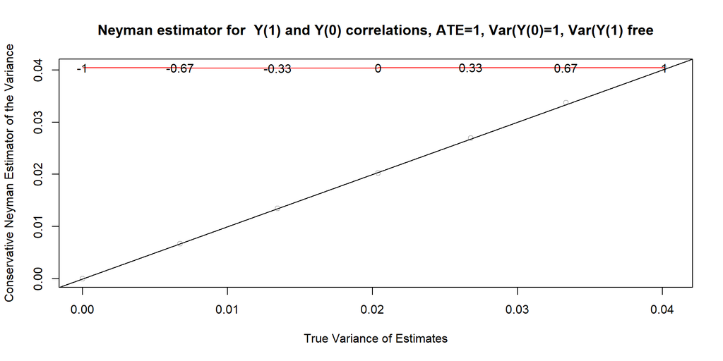

### 5.2.15 Tighter Bounds On Variance Estimate

The conservative variance comes from the fact that you do not know the covariance between $Y(1)$ and $Y(0)$.

- But as [Aronow, Green, and Lee (2014)](http://arxiv.org/pdf/1405.6555.pdf) point out, you *do* know something.
- Intuitively, if you know that the variance of $Y(1)$ is 0, then the covariance also has to be zero.
- This basic insight opens a way of calculating bounds on the variance of the sample average treatment effect.

### 5.2.16 Tighter Bounds On Variance Estimate

Example:

- Take a million-observation dataset, with treatment randomly assigned
- Assume $Y(0)=0$ for everyone and $Y(1)$ distributed normally with mean 0 and standard deviation of 1000.
- Note here the covariance of $Y(1)$ and $Y(0)$ is 0.
- Note the true variance of the estimated sample average treatment effect should be (approx) $\frac{Var(Y(1))}{{1000000}} + \frac{Var(Y(0))}{{1000000}} = 1+0=1$, for an se of $1$.
- But using the Neyman estimator (or OLS!) we estimate (approx) $\frac{Var(Y(1))}{({1000000/2})} + \frac{Var(Y(0))}{({1000000/2})} = 2$, for an se of $\sqrt{2}$.
- But we can recover the truth knowing the covariance between $Y(1)$ and $Y(0)$ is 0.

### 5.2.17 Tighter Bounds On Variance Estimate: Code

```r
sharp_var <- function(yt, yc, N=length(c(yt,yc)), upper=TRUE){

  m <- length(yt)
  n <- m + length(yc)
  V <- function(x,N) (N-1)/(N*(length(x)-1)) * sum((x - mean(x))^2)
  yt <- sort(yt)
  if(upper) {yc <- sort(yc)
  } else {
    yc <- sort(yc,decreasing=TRUE)}
  p_i <- unique(sort(c(seq(0,n-m,1)/(n-m),seq(0,m,1)/m)))-
        .Machine$double.eps^.5
  p_i[1] <- .Machine$double.eps^.5

  yti <- yt[ceiling(p_i*m)]
  yci <- yc[ceiling(p_i*(n-m))]

  p_i_minus <- c(NA,p_i[1: (length(p_i)-1)])

 ((N-m)/m * V(yt,N) + (N-(n-m))/(n-m)*V(yc,N) +
     2*sum(((p_i-p_i_minus)*yti*yci)[2:length(p_i)]) - 2*mean(yt)*mean(yc))/(N-1)}
```

### 5.2.18 Illustration

```r
n   <- 1000000
Y   <- c(rep(0,n/2), 1000*rnorm(n/2))
X   <- c(rep(0,n/2), rep(1, n/2))

lm_robust(Y~X) |> tidy() |> kable(digits = 2)
```

| term | estimate | std.error | statistic | p.value | conf.low | conf.high | df | outcome |
| --- | --- | --- | --- | --- | --- | --- | --- | --- |
| (Intercept) | 0.00 | 0.00 | 0.63 | 0.53 | 0.00 | 0.00 | 999998 | Y |
| X | 1.21 | 1.41 | 0.86 | 0.39 | -1.56 | 3.98 | 999998 | Y |

```r
kable(t(as.matrix(ols)))
```

[output not shown]

```r
c(sharp_var(Y[X==1], Y[X==0], upper = FALSE),
  sharp_var(Y[X==1], Y[X==0], upper = TRUE)) |>
  round(2)
```

```
[1] 1 1
```

The sharp bounds are $[1,1]$ but the conservative estimate is $\sqrt{2}$.

### 5.2.19 Asymptotics

- It is a remarkable thing that you can estimate the standard error straight from the data
- However, once you want to *use* the standard error to do hypothesis testing you generally end up looking up distributions ($t$-distributions or normal distributions)
- That’s a little disappointing and has been one of the criticisms made by Deaton and Cartwright (2018)

However you *can* do hypothesis testing even without an estimate of the standard error.

Up next

## 5.3 Randomization Inference

*A procedure for using the randomization distribution to calculate $p$ values*

### 5.3.1 Calculate a $p$ value in your head

- Illustrating $p$ values via “randomization inference”
- Say you randomized assignment to treatment and your data looked like this.

| Unit | 1 | 2 | 3 | 4 | 5 | 6 | 7 | 8 | 9 | 10 |
| --- | --- | --- | --- | --- | --- | --- | --- | --- | --- | --- |
| Treatment | 0 | 0 | 0 | 0 | 0 | 0 | 0 | 1 | 0 | 0 |
| Health score | 4 | 2 | 3 | 1 | 2 | 3 | 4 | 8 | 7 | 6 |

Then:

- Does the treatment improve your health?
- What’s the $p$ value for the null that treatment had no effect on anybody?

### 5.3.2 Calculate a $p$ value in your head

- Illustrating $p$ values via “randomization inference”
- Say you randomized assignment to treatment and your data looked like this.

| Unit | 1 | 2 | 3 | 4 | 5 | 6 | 7 | 8 | 9 | 10 |
| --- | --- | --- | --- | --- | --- | --- | --- | --- | --- | --- |
| Treatment | 0 | 0 | 0 | 0 | 0 | 0 | 0 | 0 | 1 | 0 |
| Health score | 4 | 2 | 3 | 1 | 2 | 3 | 4 | 8 | 7 | 6 |

Then:

- Does the treatment improve your health?
- What’s the $p$ value for the null that treatment had no effect on anybody?

### 5.3.3 Randomization Inference: Some code

- In principle it is very easy.
- These few lines generate data, produce the regression estimate and then an `ri` estimate of $p$:

```r
# data
set.seed(1)
df <- fabricate(N = 1000, Z = rep(c(0,1), N/2), Y=  .1*Z + rnorm(N))

# test stat
test.stat <- function(df) with(df, mean(Y[Z==1])- mean(Y[Z==0]))

# test stat distribution
ts <- replicate(4000, df |> mutate(Z = sample(Z)) |> test.stat())

# test
mean(ts >= test.stat(df))   # One sided p value
```

```
[1] 0.025
```

### 5.3.4 Randomization Inference: Some code

The $p$ value is the mass to the right of the vertical

```r
hist(ts); abline(v = test.stat(df), col = "red")
```

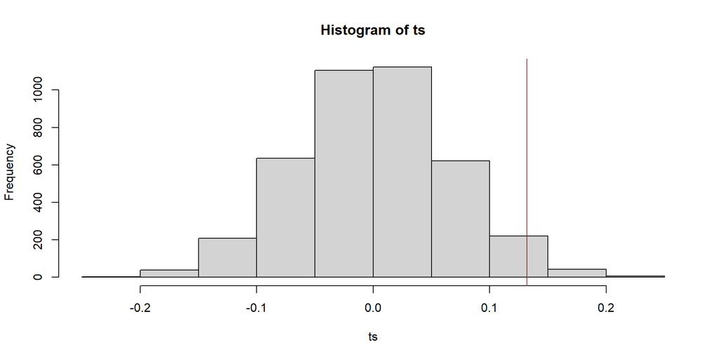

### 5.3.5 Using `ri2`

You can do the same using Alex Coppock’s [ri2](https://cloud.r-project.org/web/packages/ri2/vignettes/ri2_vignette.html) package

```r
library(ri2)

# Declare the assignment
assignment <- declare_ra(N = 1000, m = 500)

# Implement
ri2_out <- conduct_ri(
  formula = Y ~ Z,
  declaration = assignment,
  sharp_hypothesis = 0,
  data = df,
  p = "upper",
  sims = 4000
)
```

### 5.3.6 Using `ri2`

| term | estimate | upper_p_value |
| --- | --- | --- |
| Z | 0.1321367 | 0.02225 |

You’ll notice slightly different answer. This is because although the procedure is “exact” it is subject to simulation error.

### 5.3.7 Randomization Inference

- Randomization inference can get more complicated when you want to test a null other than the sharp null of no effect.
- Say you wanted to test the null that the effect is 2 for all units. How do you do it?
- Say you wanted to test the null that an *interaction effect* is zero. How do you do it?
- In both cases by filling in a potential outcomes schedule given the hypothesis in question and then generating a test statistic

| Observed Y(0) | Observed Y(1) | Under null that effect is 0 Y(0) | Under null that effect is 0 Y(1) | Under null that effect is 2 Y(0) | Under null that effect is 2 Y(1) |
| --- | --- | --- | --- | --- | --- |
| 1 | NA | 1 | 1 | 1 | 3 |
| 2 | NA | 2 | 2 | 2 | 4 |
| NA | 4 | 4 | 4 | 2 | 4 |
| NA | 3 | 3 | 3 | 1 | 3 |

### 5.3.8 `ri` and CIs

It is possible to use this procedure to generate **confidence intervals** with a natural interpretation.

- The key idea is that we can use the same procedure to assess the probability of the data given a sharp null of no effect, but also a sharp null of *any other* **constant* effect.
- We can then see what set of effects we *reject* and what set we *accept*
- We are left with a set of values that *we cannot reject* at the 0.05 level.

### 5.3.9 `ri` and CIs in practice

```r
candidates <- seq(-.05, .3, length = 50)

get_p <- function(j)
  (conduct_ri(
      formula = Y ~ Z,
      declaration = assignment,
      sharp_hypothesis = j,
      data = df,
      sims = 5000,
    ) |> summary()
  )$two_tailed_p_value

# Implement
ps <- candidates |> sapply(get_p)
```

### 5.3.10 `ri` and CIs in practice

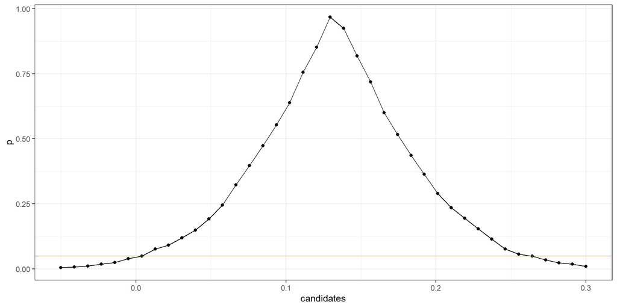

**Warning**: calculating confidence intervals this way can be computationally intensive

### 5.3.11 `ri` with `DeclareDesign`

- `DeclareDesign` can do randomization inference natively
- The trick is to ensure that when calculating the $p$ values the *only* stochastic component is the assignment to treatment when calculating the $p$ values

### 5.3.12 `ri` with `DeclareDesign` (advanced)

Here we get minimal detectable effects by using a design that has two stage simulations so we can estimate the sampling distribution of summaries of the sampling distribution generated from reassignments.

```r
test_stat <- function(data)
  with(data, data.frame(estimate = mean(Y[Z==1]) - mean(Y[Z==0])))

b <- 0

design <-
  declare_model(N = 100,  Z = complete_ra(N), Y = b*Z + rnorm(N)) +
  declare_estimator(handler = label_estimator(test_stat), label = "actual")+
  declare_measurement(Z = sample(Z))  + # this is the permutation step
  declare_estimator(handler = label_estimator(test_stat), label = "null")
```

### 5.3.13 `ri` with `DeclareDesign` (advanced)

Simulations data frame from two step simulation. Note computational intensity as number of runs is the product of the sims vector. I speed things up by using a simple estimation function and also using parallelization.

```r
library(future)
options(parallelly.fork.enable = TRUE)
plan(multicore)

simulations <-
  design |> redesign(b = c(0, .25, .5, .75, 1)) |>
  simulate_design(sims = c(200, 1, 1000, 1))
```

### 5.3.14 `ri` with `DeclareDesign` (advanced)

A snap shot of the simulations dataframe: we have multiple step 3 draws for each design and step 1 draw.

```r
simulations |> head() |> kable(digits = 2)
```

| design | b | sim_ID | estimator | estimate | step_1_draw | step_3_draw |
| --- | --- | --- | --- | --- | --- | --- |
| design_1 | 0 | 1 | actual | -0.02 | 1 | 1 |
| design_1 | 0 | 1 | null | 0.06 | 1 | 1 |
| design_1 | 0 | 2 | actual | -0.02 | 1 | 2 |
| design_1 | 0 | 2 | null | 0.03 | 1 | 2 |
| design_1 | 0 | 3 | actual | -0.02 | 1 | 3 |
| design_1 | 0 | 3 | null | -0.05 | 1 | 3 |

### 5.3.15 `ri` with `DeclareDesign` (advanced)

Power for each value of `b`.

```r
simulations |> group_by(b, step_1_draw) |>
  summarize(p = mean(abs(estimate[estimator == "null"]) >= abs(estimate[estimator == "actual"]))) |>
  group_by(b) |> summarize(power = mean(p <= .05)) |>
  ggplot(aes(b, power)) + geom_line() + geom_hline(yintercept = .8, color = "red")
```

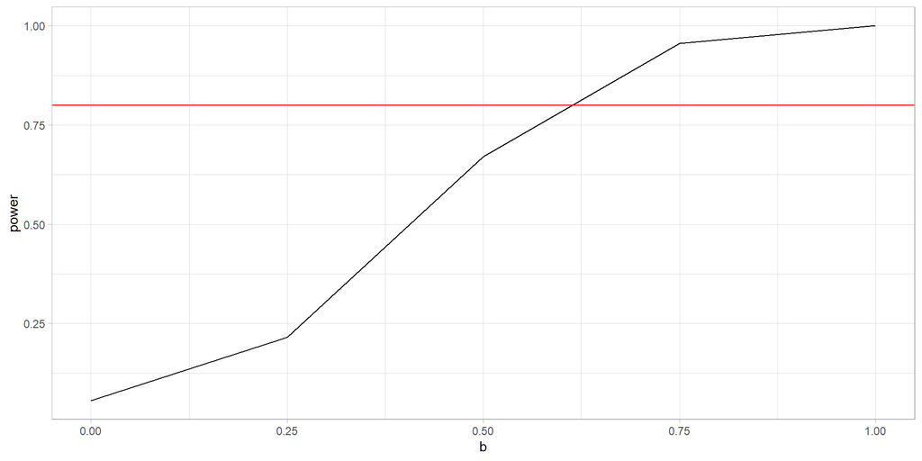

If you want to figure out more precisely what `b` gives 80% or 90% power you can narrow down the `b` range.

### 5.3.16 `ri` interactions

Lets now imagine a world with two treatments and we are interested in using `ri` for assessing the interaction. (Code from [Coppock, `ri2`](https://cloud.r-project.org/web/packages/ri2/vignettes/ri2_vignette.html))

```r
set.seed(1)

N <- 100
declaration <- randomizr::declare_ra(N = N, m = 50)

data <- fabricate(
  N = N,
  Z = conduct_ra(declaration),
  X = rnorm(N),
  Y = .9 * X + .2 * Z + .1 * X * Z + rnorm(N))
```

### 5.3.17 `ri` interactions

The approach is to declare a null model that is nested by the full model. Then $F$ test statistic from the model comparisons is taken as the test statistic and distribution of this is built up under re-randomizations.

```r
conduct_ri(
    model_1 = Y ~ Z + X,
    model_2 = Y ~ Z + X + Z * X,
    declaration = declaration,
    assignment = "Z",
    sharp_hypothesis = coef(lm(Y ~ Z, data = data))[2],
    data = data,
    sims = 1000
  )  |> summary() |> kable()
```

| term | estimate | two_tailed_p_value |
| --- | --- | --- |
| F-statistic | 1.954396 | 0.171 |

### 5.3.18 `ri` interactions with `DeclareDesign`

Let’s imagine a true model with interactions. We take an estimate. We then ask how likely that estimate is from a *null* model with constant effects

Note: this is *quite* a sharp hypothesis

```r
df <- fabricate(N = 1000, Z1 = rep(c(0,1), N/2), Z2 = sample(Z1), Y = Z1 + Z2 - .15*Z1*Z2 + rnorm(N))

my_estimate <- (lm(Y ~ Z1*Z2, data = df) |> coef())[4]

null_model <-  function(df) {
  M0 <- lm(Y ~ Z1 + Z2, data = df)
  d1 <- coef(M0)[2]
  d2 <- coef(M0)[3]
  df |> mutate(
    Y_Z1_0_Z2_0 = Y - Z1*d1 - Z2*d2,
    Y_Z1_1_Z2_0 = Y + (1-Z1)*d1 - Z2*d2,
    Y_Z1_0_Z2_1 = Y - Z1*d1 + (1-Z2)*d2,
    Y_Z1_1_Z2_1 = Y + (1-Z1)*d1 + (1-Z2)*d2)
  }
```

### 5.3.19 `ri` interactions with `DeclareDesign`

Let’s imagine a true model with interactions. We take an estimate. We then ask how likely that estimate is from a *null* model with constant effects

**Imputed** potential outcomes look like this:

```r
df <- df |> null_model()

df |>  head() |> kable(digits = 2, align = "c")
```

| ID | Z1 | Z2 | Y | Y_Z1_0_Z2_0 | Y_Z1_1_Z2_0 | Y_Z1_0_Z2_1 | Y_Z1_1_Z2_1 |
| --- | --- | --- | --- | --- | --- | --- | --- |
| 0001 | 0 | 0 | -0.18 | -0.18 | 0.76 | 0.68 | 1.61 |
| 0002 | 1 | 0 | 0.20 | -0.73 | 0.20 | 0.12 | 1.06 |
| 0003 | 0 | 0 | 2.56 | 2.56 | 3.50 | 3.42 | 4.36 |
| 0004 | 1 | 0 | -0.27 | -1.21 | -0.27 | -0.35 | 0.59 |
| 0005 | 0 | 1 | -2.13 | -2.99 | -2.05 | -2.13 | -1.19 |
| 0006 | 1 | 1 | 3.52 | 1.72 | 2.66 | 2.58 | 3.52 |

### 5.3.20 `ri` interactions with `DeclareDesign`

```r
design <-
  declare_model(data = df) +
  declare_measurement(Z1 = sample(Z1), Z2 = sample(Z2),
                      Y = reveal_outcomes(Y ~ Z1 + Z2)) +
  declare_estimator(Y ~ Z1*Z2, term = "Z1:Z2")
```

```r
diagnose_design(design, sims = 1000, diagnosands = ri_ps(my_estimate))
```

| Design | Estimator | Outcome | Term | N Sims | One Sided Pos | One Sided Neg | Two Sided |
| --- | --- | --- | --- | --- | --- | --- | --- |
| design | estimator | Y | Z1:Z2 | 1000 | 0.95 | 0.05 | 0.10 |
|  |  |  |  |  | (0.01) | (0.01) | (0.01) |

### 5.3.21 `ri` in practice

- In practice (unless you have a design declaration), it is a good idea to create a $P$ matrix when you do your randomization.
- This records the set of possible randomizations you might have had: or a sample of these.
- So, again: assignments have to be replicable

### 5.3.22 `ri` Applications

- Recall that silly randomization procedure from this slide.
- Say you forgot to take account of the wacky assignment in your estimates and you estimate 0.15.
- *Does the treatment improve your health?*: $p=?$

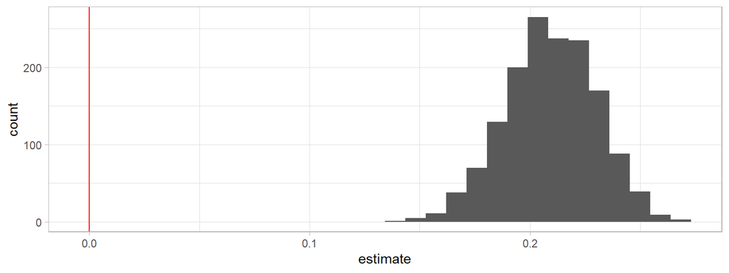

### 5.3.23 `ri` Applications

- Randomization procedures are sometimes funky in lab experiments
- Using randomization inference would force a focus on the true assignment of individuals to treatments
- Fake (but believable) example follows

### 5.3.24 `ri` Applications

|  |  | Capacity | T1 | T2 | T3 |
| --- | --- | --- | --- | --- | --- |
| Session | Thursday | 40 | 10 | 30 | 0 |
|  | Friday | 40 | 10 | 0 | 30 |
|  | Saturday | 10 | 10 | 0 | 0 |

Optimal assignment to treatment given constraints due to facilities

[output not shown]

Constraints due to subjects

### 5.3.25 `ri` Applications

If you think hard about assignment you might come up with an allocation like this.

| Subject type | N | Available | Allocations Thurs | Allocations Fri | Allocations Sat |
| --- | --- | --- | --- | --- | --- |
| A | 30 | Thurs, Fri | 15 | 15 | NA |
| B | 30 | Thurs, Sat | 25 | NA | 5 |
| C | 30 | Fri, Sat | NA | 25 | 5 |

Assignment of people to days

### 5.3.26 `ri` Applications

That allocation balances as much as possible. Given the allocation you might randomly assign individuals to different days as well as randomly assigning them to treatments within days. If you then figure out assignment propensities, this is what you would get:

| Subject type | N | Available | Assignment Probabilities T1 | Assignment Probabilities T2 | Assignment Probabilities T3 |
| --- | --- | --- | --- | --- | --- |
| A | 30 | Thurs, Fri | 0.250 | 0.375 | 0.375 |
| B | 30 | Thurs, Sat | 0.375 | 0.625 | 0.000 |
| C | 30 | Fri, Sat | 0.375 | NA | 0.625 |

### 5.3.27 `ri` Applications

Even under the assumption that the day of measurement does not matter, these assignment probabilities have big implications for analysis.

| Subject type | N | Available | Assignment Probabilities T1 | Assignment Probabilities T2 | Assignment Probabilities T3 |
| --- | --- | --- | --- | --- | --- |
| A | 30 | Thurs, Fri | 0.250 | 0.375 | 0.375 |
| B | 30 | Thurs, Sat | 0.375 | 0.625 | 0.000 |
| C | 30 | Fri, Sat | 0.375 | NA | 0.625 |

- Only the type $A$ subjects could have received any of the three treatments.
- There are no two treatments for which it is possible to compare outcomes for subpopulations $B$ and $C$
- A comparison of $T1$ versus $T2$ can only be made for population $A \cup B$
- However subpopulation $A$ is assigned to $A$ (versus $B$) with probability 4/5; while population $B$ is assigned with probability 3/8

### 5.3.28 `ri` Applications

- **Implications for design**: need to uncluster treatment delivery
- **Implications for analysis**: need to take account of propensities

**Idea**: Wacky assignments happen but if you know the propensities you can do the analysis.

### 5.3.29 `ri` Applications: Indirect assignments

A particularly interesting application is where a random assignment combines with existing features to determine an assignment to an “indirect” treatment.

- For instance: $n$ of $N$ are assigned to a treatment.
- You are interested in whether “having a friend assigned to treatment” makes a difference to a subject. Or maybe “a friend of a friend”
- That means the subject has a complex *clustered* assignment that depends on how many friends they have
- A bit mind-boggling, but:
  - Rerun your assignment many times and each time figure out whether a subject is assigned to an indirect treatment or not
  - Calculate the implied quantity of interest for each assignment
  - Assess the place of the actual quantity in the sampling distribution

## 5.4 Principle: Keep the reporting close to the design

### 5.4.1 Design-based analysis

Report the analysis that is implied by the design.

|  |  | T2 |  |  |  |
| --- | --- | --- | --- | --- | --- |
|  |  | N | Y | All | Diff |
| T1 | N | $\overline{y}_{00}$ | $\overline{y}_{01}$ | $\overline{y}_{0x}$ | $d_2\|T1=0$ |
|  |  | (sd) | (sd) | (sd) | (sd) |
|  | Y | $\overline{y}_{10}$ | $\overline{y}_{10}$ | $\overline{y}_{1x}$ | $d_2\|T1=1$ |
|  |  | (sd) | (sd) | (sd) | (sd) |
|  | All | $\overline{y}_{x0}$ | $\overline{y}_{x1}$ | $y$ | $d_2$ |
|  |  | (sd) | (sd) | (sd) | (sd) |
|  | Diff | $d_1\|T2=0$ | $d_1\|T2=1$ | $d_1$ | $d_1d_2$ |
|  |  | (sd) | (sd) | (sd) | (sd) |

This is instantly recognizable from the design and returns all the benefits of the factorial design including all main effects, conditional causal effects, interactions and summary outcomes. It is much clearer and more informative than a regression table.

# 6 Design

*Focus on randomization schemes*

## 6.1 Aims and practice

1. Goals
2. Cluster randomization
3. Blocked randomization
4. Factorial designs
5. External validity
6. Assignments with `DeclareDesign`
7. Indirect assignments

### 6.1.1 Experiments

- Experiments are investigations in which an intervention, in all its essential elements, is under the control of the investigator. (Cox & Reid)
- Two major types of control:
1. control over assignment to treatment – this is at the heart of many field experiments
2. control over the treatment itself – this is at the heart of many lab experiments
- Main focus today is on 1 and on the question: *how does control over assignment to treatment allow you to make reasonable statements about causal effects?*

### 6.1.2 Experiments

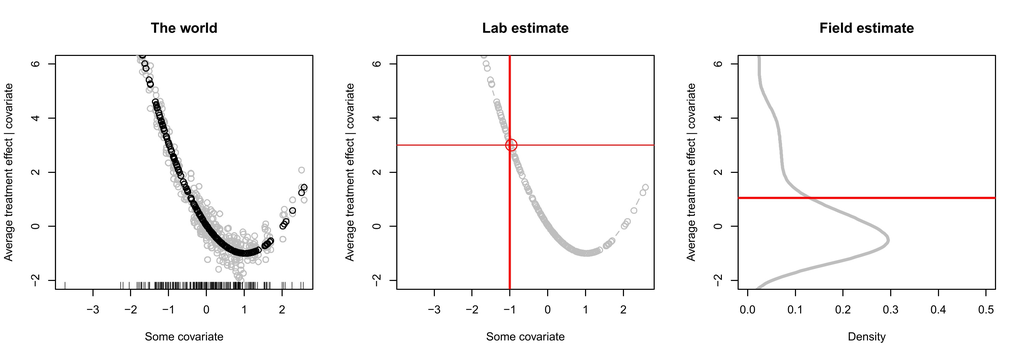

### 6.1.3 Basic randomization

- Basic randomization is very simple. For example, say you want to assign 5 of 10 units to treatment. Here is simple code:

```r
sample(0:1, 10, replace = TRUE)
```

```
 [1] 0 1 0 1 1 1 1 1 1 0
```

### 6.1.4 …should be replicable

In general you might want to set things up so that your randomization is **replicable**. You can do this by setting a **seed**:

```r
set.seed(20111112)
sample(0:1, 10, replace = TRUE)
```

```
 [1] 1 0 1 1 1 0 1 1 1 1
```

and again:

```r
set.seed(20111112)
sample(0:1, 10, replace = TRUE)
```

```
 [1] 1 0 1 1 1 0 1 1 1 1
```

### 6.1.5 Basic randomization

Even better is to set it up so that it can reproduce **lots of possible draws** so that you can check the propensities for each unit.

```r
set.seed(20111112)
P <- replicate(1000, sample(0:1, 10, replace = TRUE))
apply(P, 1, mean)
```

```
 [1] 0.519 0.496 0.510 0.491 0.524 0.514 0.535 0.497 0.470 0.506
```

Here the $P$ matrix gives 1000 possible ways of allocating 5 of 10 units to treatment. We can then confirm that the average propensity is 0.5.

- A huge advantage of this approach is that if you make a mess of the random assignment; **you can still generate the P matrix and use that for all analyses**!

### 6.1.6 Do it in advance

- Unless you need them to keep subjects at ease, leave your spinners and your dice and your cards behind.
- Especially when you have multiple or complex randomizations you are generally much better doing it with a computer in advance

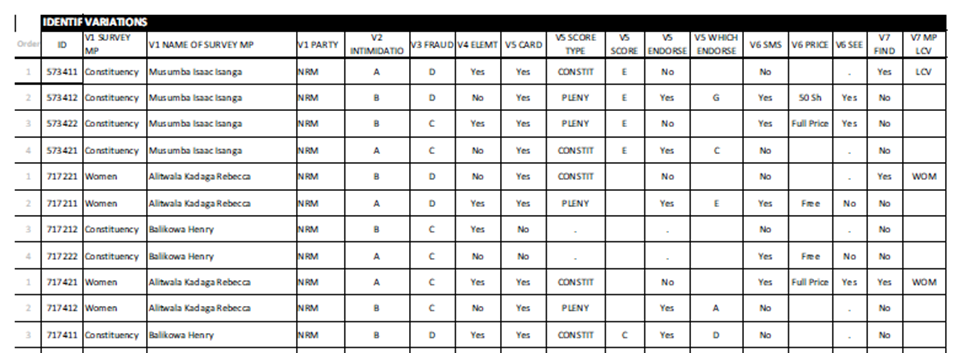

A survey dictionary with results from a complex randomization presented in a simple way for enumerators

### 6.1.7 Did the randomization ‘’work’’?

- People often wonder: did randomization work? Common practice is to implement a set of $t$-tests to see if there is balance. This makes no sense.
- If you doubt whether it was **implemented** properly do an $F$ test. If you worry about **variance**, specify controls in advance as a function of relation with outcomes (more on this later). If you worry about **conditional bias** then look at substantive differences between groups, not $t$–tests
- If you want realizations to have particular properties: *build it into the scheme in advance*.

## 6.2 Cluster Randomization

### 6.2.1 Cluster Randomization

- Simply place units into groups (clusters) and then randomly assign the groups to treatment and control.
- All units in a given group get the same treatment

**Note:** clusters are part of your design, not part of the world.

### 6.2.2 Cluster Randomization

- Often used if intervention has to function at the cluster level *or* if outcome defined at the cluster level.
- *Disadvantage:* loss of statistical power
- However: perfectly possible to assign *some* treatments at cluster level and then *other* treatments at the individual level
- **Principle:** (unless you are worried about spillovers) generally make clusters as small as possible
- **Principle:** Surprisingly, variability in cluster size makes analysis harder. Try to control assignment so that cluster sizes are similar in treatment and in control.
- **Be clear** about whether you believe effects are operating at the cluster level or at the individual level. This matters for power calculations.
- **Be clear** about whether spillover effects operate only within clusters or also across them. If within only you might be able to interpret treatment as the effect of being in a treated cluster…

### 6.2.3 Cluster Randomization: Block by cluster size

Surprisingly, if clusters are of different sizes the difference in means estimator is *not* unbiased, even if all units are assigned to treatment with the same probability.

**Here’s the intuition.**Say there are two clusters each with homogeneous treatment effects:

| Cluster | Size | Y0 | Y1 |
| --- | --- | --- | --- |
| 1 | 1000000 | 0 | 1 |
| 2 | 1 | 0 | 0 |

Then: *What is the true average treatment effect?* What do you expect to estimate from cluster random assignment?

The solution is to block by cluster size. For more see: http://gking.harvard.edu/files/cluster.pdf

## 6.3 Blocked assignments and other restricted randomizations

### 6.3.1 Blocking

There are more or less **efficient** ways to randomize.

- Randomization helps ensure good balance on all covariates (observed and unobserved) *in expectation*.
- But balance may not be so great *in realization*
- Blocking can help ensure balance ex post on observables

### 6.3.2 Blocking

Consider a case with four units and two strata. There are 6 possible assignments of 2 units to treatment:

| ID | X | Y(0) | Y(1) | R1 | R2 | R3 | R4 | R5 | R6 |
| --- | --- | --- | --- | --- | --- | --- | --- | --- | --- |
| 1 | 1 | 0 | 1 | 1 | 1 | 1 | 0 | 0 | 0 |
| 2 | 1 | 0 | 1 | 1 | 0 | 0 | 1 | 1 | 0 |
| 3 | 2 | 1 | 2 | 0 | 1 | 0 | 1 | 0 | 1 |
| 4 | 2 | 1 | 2 | 0 | 0 | 1 | 0 | 1 | 1 |
| – | – | – | – | – | – | – | – | – | – |
| $\widehat{\tau}$: |  |  |  | 0 | 1 | 1 | 1 | 1 | 2 |

Even with a constant treatment effect and everything uniform within blocks, there is variance in the estimation of $\widehat{\tau}$. This can be eliminated by excluding R1 and R6.

### 6.3.3 Blocking

Simple blocking in R (5 pairs):

```r
sapply(1:5, function(i) sample(0:1))
```

| 1 | 2 | 3 | 4 | 5 |
| --- | --- | --- | --- | --- |
| 1 | 1 | 0 | 1 | 1 |
| 0 | 0 | 1 | 0 | 0 |

### 6.3.4 Of blocks and clusters

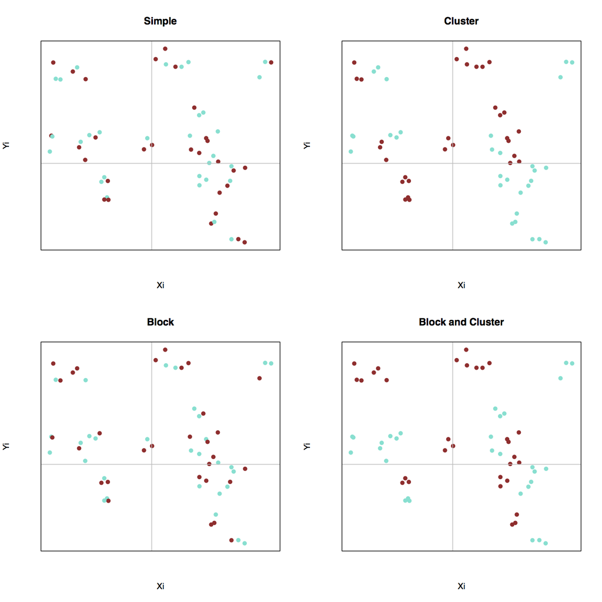

### 6.3.5 Blocking

- Blocking is a case of **restricted randomization**. Although each unit is sampled with equal probability, the *profiles* of possible assignments are not.
- You have to take account of this when doing analysis
- There are many other approaches.
  - **Matched Pairs** are a particularly fine approach to blocking
  - You could also randomize and then **replace the randomization** if you do not like the balance. This sounds tricky (and it is) but it is OK as long as you understand the true lottery process you are employing and incorporate that into analysis
  - It is even possible to block on **covariates for which you don’t have data** ex ante, by using methods in which you allocate treatment over time as a function of features of your sample (also tricky)

### 6.3.6 Other types of restricted randomization

- Really you can set whatever criterion you want for your set of treated units to have (eg no treated unit beside another treated unit; at least 5 from the north, 10 from the south, guaranteed balance by some continuous variable etc)
- You just have to be sure that you understand the random process that was used and that you can use it in the analysis stage
- But here be dragons
  - The more complex your design, the more complex your analysis.
  - General injunction http://www.ncbi.nlm.nih.gov/pubmed/15580598 ``as ye randomize so shall ye analyze’’)
  - In general you should make sure that a given randomization procedure coupled with a given estimation procedure will produce an unbiased estimate. `DeclareDesign` can help with this.

### 6.3.7 Challenges with re-randomization

- We can see that blocked and clustered assignments are actually types of restricted randomizations: they limit the set of acceptable randomizations to those with good properties
- You could therefore implement the *equivalent* distribution of assignments y specifying an acceptable rule and then re-randomizing when the rule is met
- That’s fine *but* you would then have to take account of clustering and blocking just as you do when you actually cluster or block

## 6.4 Factorial Designs

### 6.4.1 Factorial Designs

- Often when you set up an experiment you want to look at more than one treatment.
- Should you do this or not? How should you use your power?

### 6.4.2 Factorial Designs

- Often when you set up an experiment you want to look at more than one treatment.
- Should you do this or not? How should you use your power?

Load up:

|  | $T2=0$ | $T2=1$ |
| --- | --- | --- |
| T1 = 0 | $50\%$ | $0\%$ |
| T1 = 1 | $50\%$ | $0\%$ |

Spread out:

|  | $T2=0$ | $T2=1$ |
| --- | --- | --- |
| T1 = 0 | $25\%$ | $25\%$ |
| T1 = 1 | $25\%$ | $25\%$ |

### 6.4.3 Factorial Designs

- Often when you set up an experiment you want to look at more than one treatment.
- Should you do this or not? How should you use your power?

Three arm it?:

|  | $T2=0$ | $T2=1$ |
| --- | --- | --- |
| T1 = 0 | $33.3\%$ | $33.3\%$ |
| T1 = 1 | $33.3\%$ | $0\%$ |

Bunch it?:

|  | $T2=0$ | $T2=1$ |
| --- | --- | --- |
| T1 = 0 | $40\%$ | $20\%$ |
| T1 = 1 | $20\%$ | $20\%$ |

### 6.4.4 Factorial Designs

- Surprisingly, adding multiple treatments does not generally eat into your power (unless you are *decomposing* a complex treatment – then it can. Why?)
- Especially when you use a fully crossed design like the middle one above.
- Fisher: “No aphorism is more frequently repeated in connection with field trials, than that we must ask Nature few questions, or, ideally, one question, at a time. The writer is convinced that this view is wholly mistaken.”
- However – adding multiple treatments *does* alter the **interpretation** of your *average* treatment effects. If T2 is an unusual treatment for example, then half the T1 effect is measured for unusual situations.

This speaks to “spreading out.” Note: the “bunching” example may not pay off and has undesireable feature of introducing a correlation between treatment assignments.

### 6.4.5 Factorial Designs

Two ways to do favtial assignments in `DeclareDesign`:

```r
# Block the second assignment
declare_assignment(Z1 = complete_ra(N)) +
declare_assignment(Z2 = block_ra(blocks = Z1)) +

# Recode four arms
declare_assignment(Z = complete_ra(N, num_arms = 4)) +
declare_measurement(Z1 = (Z == "T2" | Z == "T4"),
                      Z2 = (Z == "T3" | Z == "T4"))
```

### 6.4.6 Factorial Designs: In practice

- In practice if you have a lot of treatments it can be hard to do full factorial designs – there may be too many combinations.
- In such cases people use **fractional factorial designs**, like the one below (5 treatments but only 8 units!)

| Variation | T1 | T2 | T3 | T4 | T5 |
| --- | --- | --- | --- | --- | --- |
| 1 | 0 | 0 | 0 | 1 | 1 |
| 2 | 0 | 0 | 1 | 0 | 0 |
| 3 | 0 | 1 | 0 | 0 | 1 |
| 4 | 0 | 1 | 1 | 1 | 0 |
| 5 | 1 | 0 | 0 | 1 | 0 |
| 6 | 1 | 0 | 1 | 0 | 1 |
| 7 | 1 | 1 | 0 | 0 | 0 |
| 8 | 1 | 1 | 1 | 1 | 1 |

### 6.4.7 Factorial Designs: In practice

- Then randomly assign units to rows. Note columns might also be blocking covariates.
- In R, look at `library(survey)`

### 6.4.8 Factorial Designs: In practice

- But be careful: you have to be comfortable with possibly not having any simple counterfactual unit for any unit (invoke sparsity-of-effects principle).

| Unit | T1 | T2 | T3 | T4 | T5 |
| --- | --- | --- | --- | --- | --- |
| 1 | 0 | 0 | 0 | 1 | 1 |
| 2 | 0 | 0 | 1 | 0 | 0 |
| 3 | 0 | 1 | 0 | 0 | 1 |
| 4 | 0 | 1 | 1 | 1 | 0 |
| 5 | 1 | 0 | 0 | 1 | 0 |
| 6 | 1 | 0 | 1 | 0 | 1 |
| 7 | 1 | 1 | 0 | 0 | 0 |
| 8 | 1 | 1 | 1 | 1 | 1 |

- In R, look at `library(survey)`

### 6.4.9 Controversy?

Muralidharan, Romero, and Wüthrich (2023) write:

> Factorial designs are widely used to study multiple treatments in one experiment. While t-tests using a fully-saturated “long” model provide valid inferences, “short” model t-tests (that ignore interactions) yield higher power if interactions are zero, but incorrect inferences otherwise. Of 27 factorial experiments published in top-5 journals (2007–2017), 19 use the short model. After including interactions, over half of their results lose significance. […]

## 6.5 External Validity: Can randomization strategies help?

### 6.5.1 Principle: Address **external validity** at the design stage

Anything to be done on randomization to address external validity concerns?

- **Note 1**: There is little or nothing about field experiments that makes the external validity problem greater for these than for other forms of ‘’sample based’’ research
- **Note 2**: Studies that use up the available universe (cross national studies) actually have a distinct external validity problem
- Two ways to think about external validity issues:
  1. Are things likely to operate in other units like they operate in these units? (even with the same intervention)
  2. Are the processes in operation in this treatment likely to operate in other treatments? (even in this population)

### 6.5.2 Principle: Address **external validity** at the design stage

- Two ways to think about external validity issues:
  1. Are things likely to operate in other units like they operate in these units? (even with the same intervention) 2.Are the processes in operation in this treatment likely to operate in other treatments? (even in this population)
- Two approaches for 1.
  - Try to sample cases and estimate *population average treatment effects*
  - Exploit internal variation: block on features that make the case unusal and assess importance of these (eg is unit poor? assess how effects differ in poor and wealthy components)
- 2 is harder and requires a sharp identification of context free primitives, if there are such things.

## 6.6 Assignments with `DeclareDesign`

### 6.6.1 A design: Multilevel data

A design with hierarchical data and different assignment schemes.

```r
design <-
  declare_model(
    school = add_level(N = 16,
                       u_school = rnorm(N, mean = 0)),
    classroom = add_level(N = 4,
                  u_classroom = rnorm(N, mean = 0)),
    student =  add_level(N = 20,
                         u_student = rnorm(N, mean = 0))
    ) +
  declare_model(
    potential_outcomes(Y ~ .1*Z + u_classroom + u_student + u_school)
    ) +
  declare_assignment(Z = simple_ra(N)) +
  declare_measurement(Y = reveal_outcomes(Y ~ Z))  +
  declare_inquiry(ATE = mean(Y_Z_1 - Y_Z_0)) +
  declare_estimator(Y ~ Z, .method = difference_in_means)
```

### 6.6.2 Sample data

Here are the first couple of rows and columns of the resulting data frame.

```r
my_data <- draw_data(design)
kable(head(my_data), digits = 2)
```

| school | u_school | classroom | u_classroom | student | u_student | Y_Z_0 | Y_Z_1 | Z | Y |
| --- | --- | --- | --- | --- | --- | --- | --- | --- | --- |
| 01 | 1.35 | 01 | 1.26 | 0001 | -1.28 | 1.33 | 1.43 | 0 | 1.33 |
| 01 | 1.35 | 01 | 1.26 | 0002 | 0.79 | 3.40 | 3.50 | 1 | 3.50 |
| 01 | 1.35 | 01 | 1.26 | 0003 | -0.12 | 2.49 | 2.59 | 0 | 2.49 |
| 01 | 1.35 | 01 | 1.26 | 0004 | -0.65 | 1.96 | 2.06 | 1 | 2.06 |
| 01 | 1.35 | 01 | 1.26 | 0005 | 0.36 | 2.97 | 3.07 | 1 | 3.07 |
| 01 | 1.35 | 01 | 1.26 | 0006 | -0.96 | 1.65 | 1.75 | 0 | 1.65 |

### 6.6.3 Sample data

Here is the distribution between treatment and control:

```r
kable(t(as.matrix(table(my_data$Z))),
      col.names = c("control", "treatment"))
```

| control | treatment |
| --- | --- |
| 645 | 635 |

### 6.6.4 Complete Random Assignment using the built in function

```r
assignment_complete <-   declare_assignment(Z = complete_ra(N))

design_complete <-
  replace_step(design, "assignment", assignment_complete)
```

### 6.6.5 Data from complete assignment

We can draw a new set of data and look at the number of subjects in the treatment and control groups.

```r
set.seed(1:5)
data_complete <- draw_data(design_complete)

kable(t(as.matrix(table(data_complete$Z))))
```

| 0 | 1 |
| --- | --- |
| 640 | 640 |

### 6.6.6 Plotted

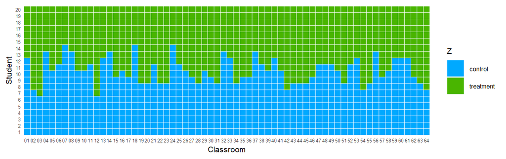

### 6.6.7 Block Random Assignment

- The treatment and control group will **in expectation** contain the same share of students in different classrooms.
- But as we saw this does necessarily hold in **realization**
- We make this more obvious by sorting the students by treatment status with schools

### 6.6.8 Blocked design

```r
assignment_blocked <-
  declare_assignment(Z = block_ra(blocks = classroom))

estimator_blocked <-
  declare_estimator(Y ~ Z, blocks = classroom,
                    .method = difference_in_means)

design_blocked <-
  design |>
  replace_step("assignment", assignment_blocked) |>
  replace_step("estimator", estimator_blocked)
```

### 6.6.9 Illustration of blocked assignment

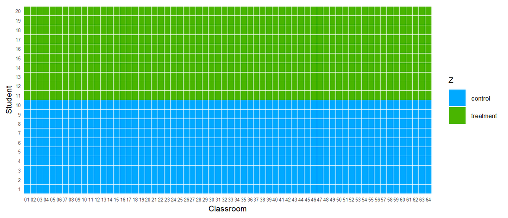

### 6.6.10 Clustering

But what if all students in a given class have to be assigned the same treatment?

```r
assignment_clustered <-
  declare_assignment(Z = cluster_ra(clusters = classroom))
estimator_clustered <-
  declare_estimator(Y ~ Z, clusters = classroom,
                    .method = difference_in_means)


design_clustered <-
  design |>
  replace_step("assignment", assignment_clustered) |>
  replace_step("estimator", estimator_clustered)
```

### 6.6.11 Illustration of clustered assignment

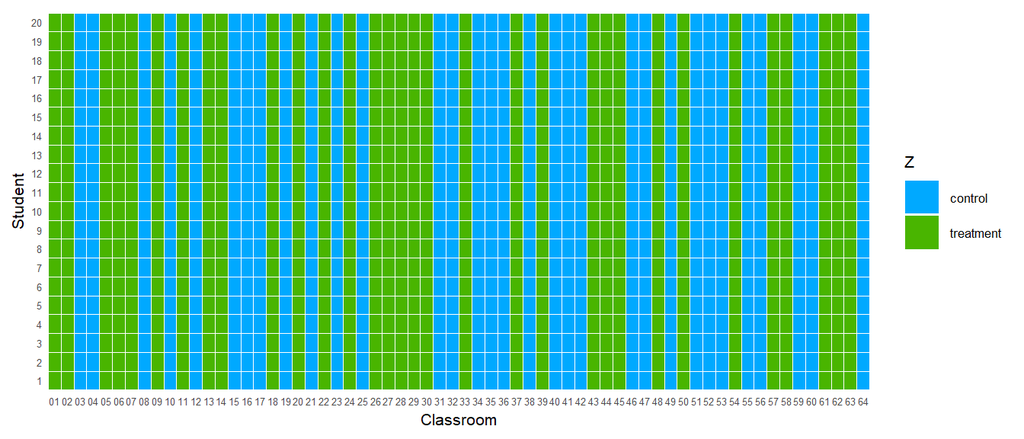

### 6.6.12 Clustered and Blocked

```r
assignment_clustered_blocked <-
  declare_assignment(Z = block_and_cluster_ra(blocks = school,
                                              clusters = classroom))
estimator_clustered_blocked <-
  declare_estimator(Y ~ Z, blocks = school, clusters = classroom,
                    .method = difference_in_means)


design_clustered_blocked <-
  design |>
  replace_step("assignment", assignment_clustered_blocked) |>
  replace_step("estimator", estimator_clustered_blocked)
```

### 6.6.13 Illustration of clustered and blocked assignment

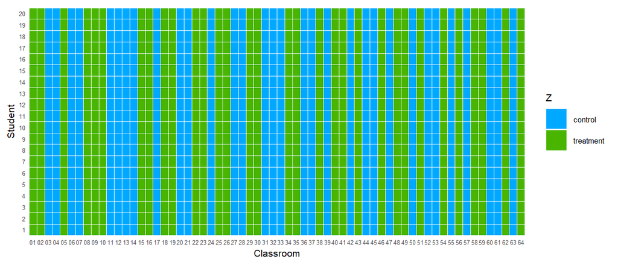

### 6.6.14 Illustration of efficiency gains from blocking

```r
designs <-
  list(
    simple = design,
    complete = design_complete,
    blocked = design_blocked,
    clustered = design_clustered,
    clustered_blocked = design_clustered_blocked)
```

```r
diagnoses <- diagnose_design(designs)
```

### 6.6.15 Illustration of efficiency gains from blocking

| Design | Power | Coverage |
| --- | --- | --- |
| simple | 0.16 | 0.95 |
|  | (0.01) | (0.01) |
| complete | 0.20 | 0.96 |
|  | (0.01) | (0.01) |
| blocked | 0.42 | 0.95 |
|  | (0.01) | (0.01) |
| clustered | 0.06 | 0.96 |
|  | (0.01) | (0.01) |
| clustered_blocked | 0.08 | 0.96 |
|  | (0.01) | (0.01) |

### 6.6.16 Sampling distributions

```r
diagnoses$simulations_df |>
  mutate(design = factor(design, c("blocked", "complete", "simple", "clustered_blocked", "clustered"))) |>
  ggplot(aes(estimate)) +
  geom_histogram() + facet_grid(~design)
```

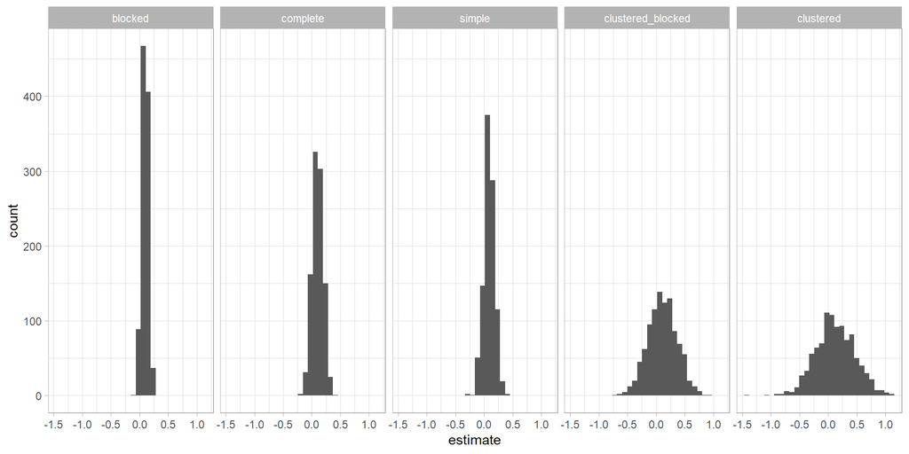

### 6.6.17 Nasty integer issues

- In many designs you seek to assign an integer number of subjects to treatment from some set.
- Sometimes however your assignment targets are not integers.

Example:

- I have 12 subjects in four blocks of 3 and I want to assign each subject to treatment with a 50% probability.

Two strategies:

1. I randomly set a target of either 1 or 2 for each block and then do complete assignment in each block. This can result in the numbers treated varying from 4 to 8
2. I randomly assign a target of 1 for two blocks and 2 for the other two blocks: **Intuition**–set a floor for the minimal target and then distribue the residual probability across blocks

### 6.6.18 Nasty integer issues

```r
# remotes::install_github("macartan/probra")
library(probra)
set.seed(1)

blocks <- rep(1:4, each = 3)

table(blocks, prob_ra(blocks = blocks))
```

```
blocks 0 1
     1 1 2
     2 1 2
     3 2 1
     4 2 1
```

```r
table(blocks, block_ra(blocks = blocks))
```

```
blocks 0 1
     1 1 2
     2 2 1
     3 1 2
     4 1 2
```

### 6.6.19 Nasty integer issues

Can also be used to set targets

```r
# remotes::install_github("macartan/probra")
library(probra)
set.seed(1)

fabricate(N = 4,  size = c(47, 53, 87, 25), n_treated = prob_ra(.5*size)) %>%
  janitor::adorn_totals("row") |>
  kable(caption = "Setting targets to get 50% targets with minimal variance")
```

Setting targets to get 50% targets with minimal variance

| ID | size | n_treated |
| --- | --- | --- |
| 1 | 47 | 23 |
| 2 | 53 | 27 |
| 3 | 87 | 43 |
| 4 | 25 | 13 |
| Total | 212 | 106 |

### 6.6.20 Nasty integer issues

Can also be used to set for complete assignment with heterogeneous propensities

```r
set.seed(1)

df <- fabricate(N = 100,  p = seq(.1, .9, length = 100), Z = prob_ra(p))

mean(df$Z)
```

```
[1] 0.5
```

```r
df |> ggplot(aes(p, Z)) + geom_point() + theme_bw()
```

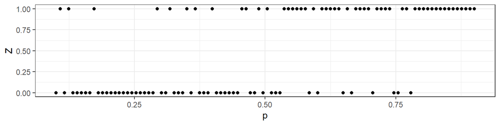

## 6.7 Indirect assignments

*Indirect control*

### 6.7.1 Indirect assignments

Indirect assignments are generally generated by applying a direct assignment and then figuring our an implied indirect assignment

```r
set.seed(1)

df <-
  fabricate(
    N = 100,
    latitude = runif(N),
    longitude = runif(N))

adjacency <-
  sapply(1:nrow(df), function(i)
    1*((df$latitude[i] - df$latitude)^2 + (df$longitude[i] - df$longitude)^2)^.5 < .1)

diag(adjacency) <- 0
```

### 6.7.2 Indirect assignments: Adjacency matrix

```r
adjacency |>
  reshape2::melt(c("x", "y"), value.name = "close") |> mutate(close = factor(close)) |>
  ggplot(aes(x=x,y=y,fill=close))+
  geom_tile() + xlab("individual") + ylab("individual") + theme_bw() +
  scale_fill_grey(start = 1, end = 0)  # 1 = white, 0 = black
```

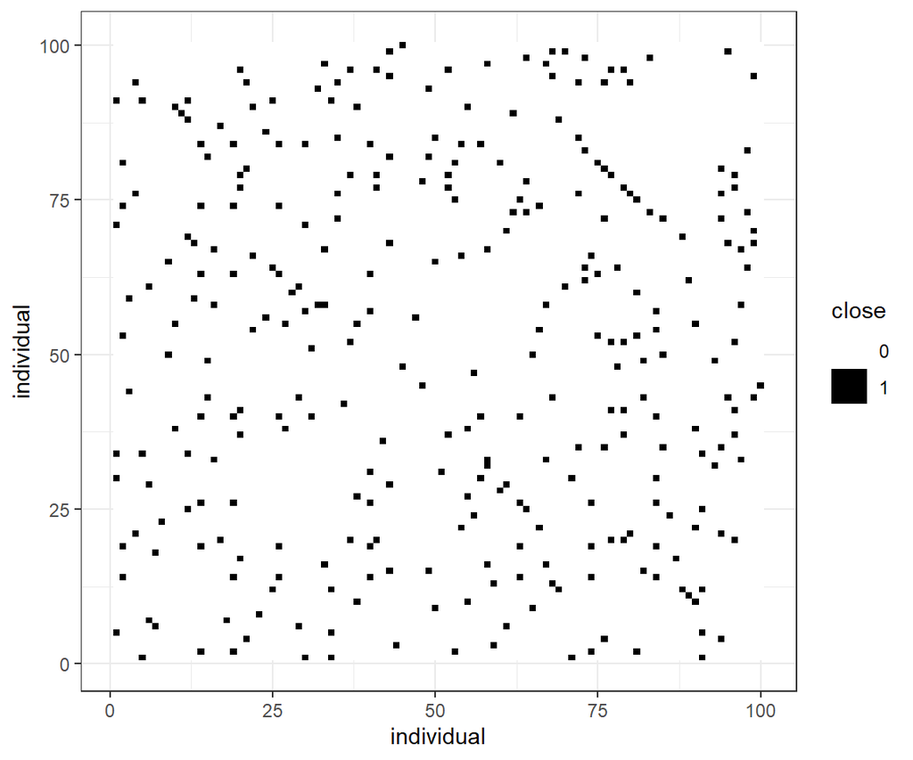

### 6.7.3 Indirect assignments

```r
n_assigned <- 50

design <-
  declare_model(data = df) +
  declare_assignment(
    direct = complete_ra(N, m = n_assigned),
    indirect = 1*(as.vector(as.vector(direct) %*% adjacency) >= 1))

draw_data(design) |> with(table(direct, indirect))
```

```
      indirect
direct  0  1
     0 13 37
     1 13 37
```

### 6.7.4 Indirect assignments: Properties

```r
indirect_propensities <- replicate(5000, draw_data(design)$indirect) |>
  apply(1, mean)
```

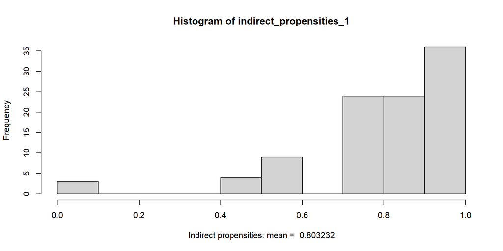

### 6.7.5 Indirect assignments: Properties

```r
df |> ggplot(aes(latitude, longitude, label = round(indirect_propensities_1, 2))) + geom_text()
```

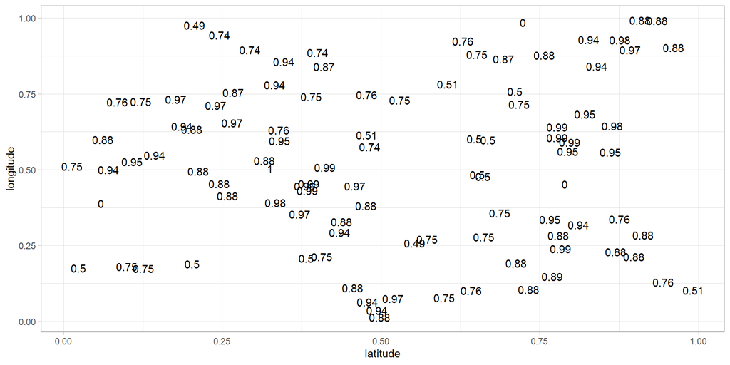

### 6.7.6 Indirect assignments: Redesign

```r
replicate(5000, draw_data(design |> redesign(n_assigned = 25))$indirect) |>
  apply(1, mean)
```

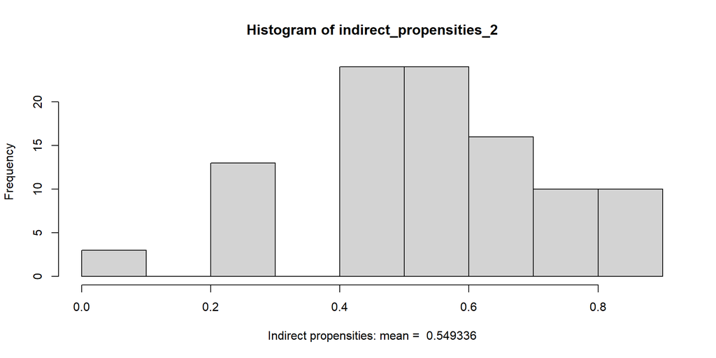

### 6.7.7 Indirect assignments: Redesign

```r
df |> ggplot(aes(latitude, longitude, label = round(indirect_propensities_2, 2))) +
  geom_text()
```

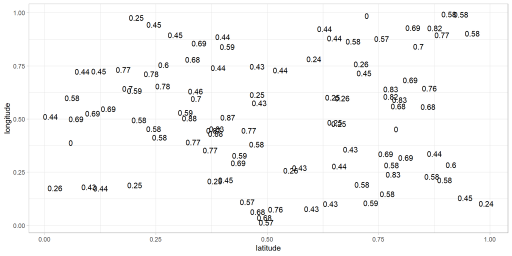

Looks better: *but there are trade offs between the direct and indirect distributions*

Figuring out the optimal procedure requires full diagnosis

# 7 Design diagnosis

*A focus on power*

## 7.1 Outline

1. Tests review
2. $p$ values and significance
3. Power
4. Sources of power
5. Advanced applications

## 7.2 Tests

### 7.2.1 Review

In the classical approach to testing a hypothesis we ask:

**How likely are we to see data like this if indeed the hypothesis is true?**

- If the answer is “not very likely” then we treat the hypothesis as suspect.
- If the answer is *not* “not very likely” then the hypothesis is maintained (some say “accepted” but this is tricky as you may want to “maintain” multiple incompatible hypotheses)

How unlikely is “not very likely”?

### 7.2.2 Weighing Evidence

When we test a hypothesis we decide first on what sort of evidence we need to see in order to decide that the hypothesis is not reliable.

- **Othello** has a hypothesis that Desdemona is innocent.
- **Iago** confronts him with evidence:
  - See how she looks at him: would she look a him like that if she were innocent?
  - … would she defend him like that if she were innocent?
  - … would he have her handkerchief if she were innocent?
  - Othello, the chances of all of these things arising if she were innocent is surely less than 5%

### 7.2.3 Hypotheses are often rejected, sometimes maintained, but rarely accepted

- Note that Othello is focused on the probability of the events if she were innocent but not the probability of the events if Iago were trying to trick him.
- He is not assessing his belief in whether she is faithful, but rather how likely the data would be if she were faithful.

So:

- He assesses: $\Pr(\text{Data} | \text{Hypothesis is TRUE})$
- While a Bayesian would assess: $\Pr(\text{Hypothesis is TRUE} | \text{Data})$

### 7.2.4 Recap: Calculate a $p$ value in your head

- Illustrating $p$ values via “randomization inference”
- Say you randomized assignment to treatment and your data looked like this.

| Unit | 1 | 2 | 3 | 4 | 5 | 6 | 7 | 8 | 9 | 10 |
| --- | --- | --- | --- | --- | --- | --- | --- | --- | --- | --- |
| Treatment | 0 | 0 | 0 | 0 | 0 | 0 | 0 | 1 | 0 | 0 |
| Health score | 4 | 2 | 3 | 1 | 2 | 3 | 4 | 8 | 7 | 6 |

Then:

- Does the treatment improve your health?
- What’s the $p$ value for the null that treatment had no effect on anybody?

## 7.3 Power

## 7.4 What power is

Power is just the probability of getting a significant result rejecting a hypothesis.

Simple enough but it presupposes:

- A well defined hypothesis
- An actual stipulation of the world under which you evaluate the probability
- A procedure for producing results and determining of they are significant / rejecting a hypothesis

### 7.4.1 By hand

I want to test the hypothesis that a six never comes up on this dice.

Here’s my **test**:

- I will roll the dice **once**.
- If a six comes up I will reject the hypothesis.

What is the power of this test?

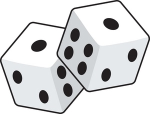

### 7.4.2 By hand

I want to test the hypothesis that a six never comes up on this dice.

Here’s my **test**:

- I will roll the dice **twice**.
- If a six comes up **either time** I will reject the hypothesis.

What is the power of *this* test?

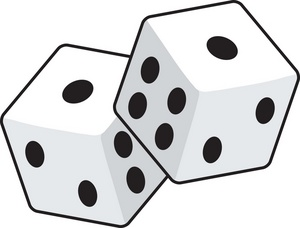

### 7.4.3 Two probabilities

Power sometimes seems more complicated because hypothesis rejection involves a calculated probability and so you need the probability of a probability.

I want to test the hypothesis that this dice is *fair*.

Here’s my **test**:

- I will roll the dice **1000** times and if I see fewer than *x* 6s or more than *y* 6s I will reject the hypothesis.

Now:

- What should *x* and *y* be?
- What is the power of this test?

### 7.4.4 Step 1: When do you reject?

For this we need to figure a rule for rejection. This is based on identifying events that should be unlikely under the hypothesis.

Here is how many 6’s I would expect if the dice is fair:

```r
fabricate(N = 1001, sixes = 0:1000, p = dbinom(sixes, 1000, 1/6)) |>
  ggplot(aes(sixes, p)) + geom_line()
```

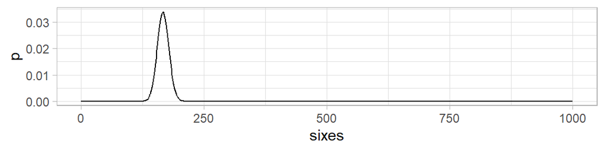

### 7.4.5 Step 1: When do you reject?

I can figure out from this that 143 or fewer is really very few and 190 or more is really very many:

```r
c(lower = pbinom(143, 1000, 1/6), upper = 1 - pbinom(189, 1000, 1/6))
```

```
     lower      upper
0.02302647 0.02785689
```

### 7.4.6 Step 2: What is the power?

- Now we need to stipulate some belief about how the world really works—this is not the null hypothesis that we plan to reject, but something that we actually take to be true.
- For instance: we think that *in fact* sixes appear 20% of the time.

Now what’s the probability of seeing at least 190 sixes?

```r
1 - pbinom(189, 1000, .2)
```

```
[1] 0.796066
```

So given I think 6s appear 20% of the time, I think it likely I’ll see at least 190 sixes and reject the hypothesis of a fair dice.

### 7.4.7 Rule of thumb

- 80% or 90% is a common rule of thumb for “sufficient” power
- but really, how much power you need depends on the purpose

### 7.4.8 Think about

- Are there other tests I could have implemented?
- Are there other ways to improve this test?

### 7.4.9 Subtleties

- Is a significant result from an underpowered study less credible? (only if there is a significance filter)
- What significance level should you choose for power? (Obviously the stricter the level the lower the power, so use what you will use when you actually implement tests)
- Do you really have to know the effect size to do power analysis? (No, but you should know at least what effects sizes you would want to be sure about picking up if they were present)
- Power is just one of many possible diagnosands
- What’s power for Bayesians?

### 7.4.10 Power analytics

Simplest intuition on power:

What is the probability of getting a significant estimate given the sampling distribution is centered on $b$ and the *standard error* is 1?

- Probability below -1.96: $F(-1.96 | \tau))$
- Probability above -1.96: $1-F(1.96 | \tau)$

Add these together: probability of getting an estimate above 1.96 or below -1.96.

```r
power <- function(b, alpha = 0.05, critical = qnorm(1-alpha/2))

  1 - pnorm(critical, mean = abs(b)) + pnorm(-critical, mean = abs(b))
```

```r
power(0)
```

```
[1] 0.05
```

```r
power(1.96)
```

```
[1] 0.5000586
```

```r
power(-1.96)
```

```
[1] 0.5000586
```

```r
power(3)
```

```
[1] 0.8508388
```

### 7.4.11 Power analytics: graphed

See:

```r
pwrss::power.z.test(ncp = 1.96, alpha = 0.05, alternative = "not equal", plot = TRUE)
```

[output not shown]

### 7.4.12 Power analytics: graphed

Substantively: if in expectation an estimate will be *just* significant, then your power is 50%

### 7.4.13 Equivalent

```r
power <- function(b, alpha = 0.05, critical = qnorm(1-alpha/2))

  1 - pnorm(critical - b) + pnorm(-critical - b)

power(1.96)
```

```
[1] 0.5000586
```

Intuition:

```r
x <- seq(-3, 3, .01)
plot(x, dnorm(x), main = "power associated with effect of 1 se")
abline(v = 1.96 - 1)
abline(v = -1.96 - 1)
```

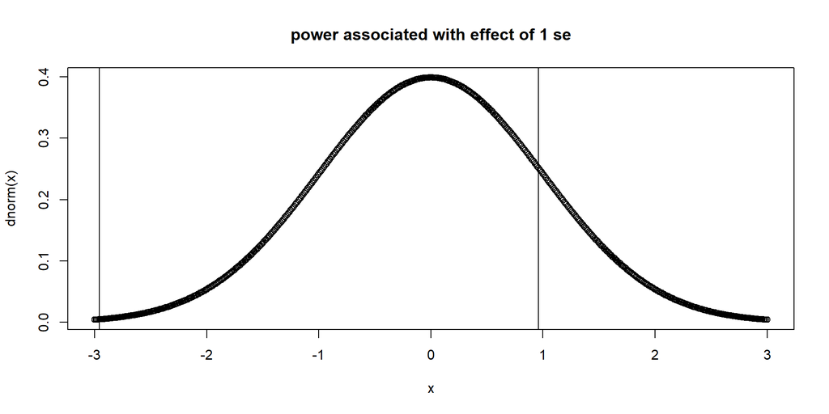

### 7.4.14 Power analytics for a trial: by hand

- Of course the standard error will depend on the number of units and the variance of outcomes in treatment and control.
- Say $N$ subject are divided into two groups and potential outcomes have standard deviation $\sigma$ in treatment and control. Then the conservative variance of the treatment effect is (approx / conservatively):

$$Var(\tau)=\frac{\sigma^2}{N/2} + \frac{\sigma^2}{N/2} = 4\frac{\sigma^2}{N}$$

and so the (conservative / approx) standard error is:

$$\sigma_\tau=\frac{2\sigma}{\sqrt{N}}$$

Note here we seem to be using the actual standard error but of course the tests we actually run will use an *estimate* of the standard error…

### 7.4.15 Power analytics for a trial: by hand

```r
se <- function(sd, N) (N/(N-1))^.5*2*sd/(N^.5)


power_2 <- function(b, alpha = .05, sd = 1, N = 100, critical = qnorm(1-alpha/2), se = 2*sd/N^.5)

  1 - pnorm(critical, mean = abs(b)/se(sd, N)) + pnorm(-critical, mean = abs(b)/se(sd, N))

power_2(0)
```

```
[1] 0.05
```

```r
power_2(.5)
```

```
[1] 0.7010827
```

### 7.4.16 Power analytics for a trial: flexible

This can be done e.g. with `pwrss` like this:

```r
pwrss::pwrss.t.2means(mu1 = .2, mu2 = .1, sd1 = 1, sd2 = 1,
               n2 = 50, alpha = 0.05,
               alternative = "not equal")
```

```
+--------------------------------------------------+
|                POWER CALCULATION                 |
+--------------------------------------------------+

Welch's T-Test (Independent Samples)

---------------------------------------------------
Hypotheses
---------------------------------------------------
  H0 (Null Claim) : d - null.d = 0
  H1 (Alt. Claim) : d - null.d != 0

---------------------------------------------------
Results
---------------------------------------------------
  Sample Size            = 50 and 50
  Type 1 Error (alpha)   = 0.050
  Type 2 Error (beta)    = 0.921
  Statistical Power      = 0.079  <<
```

```r
power_2(.50, N = 100)
```

```
[1] 0.7010827
```

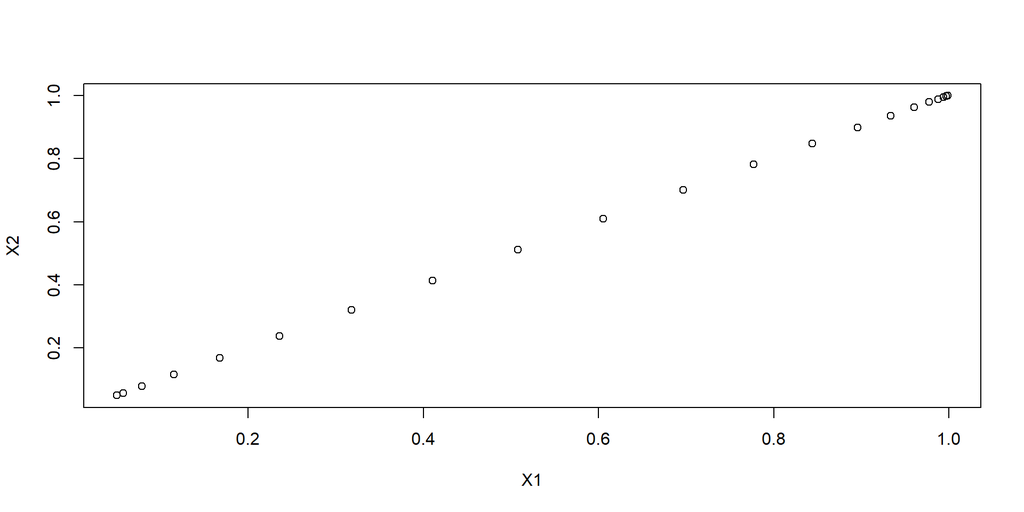

### 7.4.17 Power for more complex trials: Analytics

Mostly involve figuring out the standard error.

Consider a cluster randomized trial, with each unit having a cluster level shock $\epsilon_k$ and an individual shock $\nu_i$. Say these have variances $\sigma^2_k$, $\sigma^2_i$.

The standard error is:

$$\sqrt{\frac{4\sigma^2_k}{K} + \frac{4\sigma^2_i}{nK}}$$

Define $\rho = \frac{\sigma^2_k}{\sigma^2_k + \sigma^2_i}$

$$\sqrt{\rho \frac{4\sigma^2}{K} + (1- \rho)\frac{4\sigma^2}{nK}}$$

$$\sqrt{((n - 1)\rho + 1)\frac{4\sigma^2}{nK}}$$

where

- $((n - 1)\rho + 1)$ is the “design effect”
- $\frac{nK}{((n - 1)\rho + 1)}$ is the “effective sample size”

Plug in these standard errors and proceed as before

### 7.4.18 Power via design diagnosis

*Is arbitrarily flexible*

```r
N <- 100
b <- .5

design <-
  declare_model(N = N,
    U = rnorm(N),
    potential_outcomes(Y ~ b * Z + U)) +
  declare_assignment(Z = simple_ra(N),
                     Y = reveal_outcomes(Y ~ Z)) +
  declare_inquiry(ate = mean(Y_Z_1 - Y_Z_0)) +
  declare_estimator(Y ~ Z, inquiry = "ate", .method = lm_robust)
```

### 7.4.19 Run it many times

```r
sims_1 <- simulate_design(design)

sims_1 |> select(sim_ID, estimate, p.value)
```

| sim_ID | estimate | p.value |
| --- | --- | --- |
| 1 | 0.24 | 0.22 |
| 2 | 0.80 | 0.00 |
| 3 | 0.25 | 0.16 |
| 4 | 0.27 | 0.18 |
| 5 | 0.87 | 0.00 |
| 6 | 0.57 | 0.00 |

### 7.4.20 Power is mass of the sampling distribution of decisions under the model

```r
sims_1 |>
  ggplot(aes(p.value)) +
  geom_histogram() +
  geom_vline(xintercept = .05, color = "red")
```

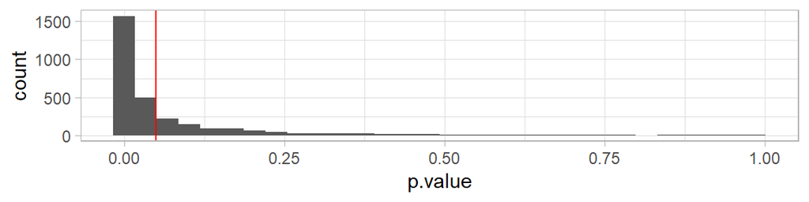

### 7.4.21 Power is mass of the sampling distribution of decisions under the model

Obviously related to the estimates you might get

```r
sims_1 |>
  mutate(significant = p.value <= .05) |>
  ggplot(aes(estimate, p.value, color = significant)) +
  geom_point()
```

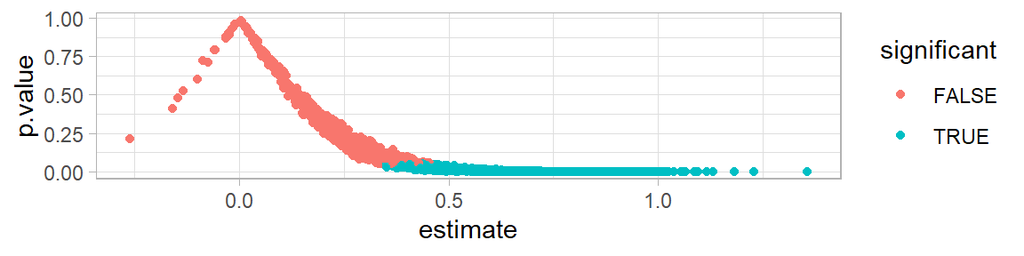

### 7.4.22 Check coverage is correct

```r
sims_1 |>
  mutate(within = (b > sims_1$conf.low) & (b < sims_1$conf.high)) |>
  pull(within) |> mean()
```

```
[1] 0.944
```

### 7.4.23 Check validity of $p$ value

A valid $p$-value satisfies $\Pr(p≤x)≤x$ for every $x \in[0,1]$ (under the null)

```r
sims_2 <-

  redesign(design, b = 0) |>

  simulate_design()
```

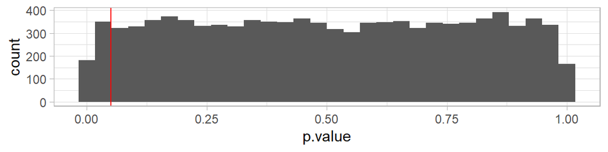

### 7.4.24 Design diagnosis does it all (over multiple designs)

```r
  diagnose_design(design)
```

| Mean Estimate | Bias | SD Estimate | RMSE | Power | Coverage |
| --- | --- | --- | --- | --- | --- |
| 0.50 | -0.00 | 0.20 | 0.20 | 0.69 | 0.95 |
| (0.00) | (0.00) | (0.00) | (0.00) | (0.00) | (0.00) |

### 7.4.25 Design diagnosis does it all

```r
design |>
  redesign(b = c(0, 0.25, 0.5, 1)) |>
  diagnose_design()
```

| b | Mean Estimate | Bias | SD Estimate | RMSE | Power | Coverage |
| --- | --- | --- | --- | --- | --- | --- |
| 0 | 0.00 | 0.00 | 0.20 | 0.20 | 0.05 | 0.95 |
|  | (0.00) | (0.00) | (0.00) | (0.00) | (0.00) | (0.00) |
| 0.25 | 0.25 | 0.00 | 0.20 | 0.20 | 0.24 | 0.95 |
|  | (0.00) | (0.00) | (0.00) | (0.00) | (0.00) | (0.00) |
| 0.5 | 0.50 | -0.00 | 0.20 | 0.20 | 0.69 | 0.95 |
|  | (0.00) | (0.00) | (0.00) | (0.00) | (0.00) | (0.00) |
| 1 | 1.00 | -0.00 | 0.20 | 0.20 | 1.00 | 0.95 |
|  | (0.00) | (0.00) | (0.00) | (0.00) | (0.00) | (0.00) |

### 7.4.26 Diagnose over multiple moving parts (and ggplot)

```r
design |>
  ## Redesign
  redesign(b = c(0.1, 0.3, 0.5), N = 100, 200, 300) |>
  ## Diagnosis
  diagnose_design() |>
  ## Prep
  tidy() |>
  filter(diagnosand == "power") |>
  ## Plot
  ggplot(aes(N, estimate, color = factor(b))) +
  geom_line()
```

### 7.4.27 Diagnose over multiple moving parts (and ggplot)

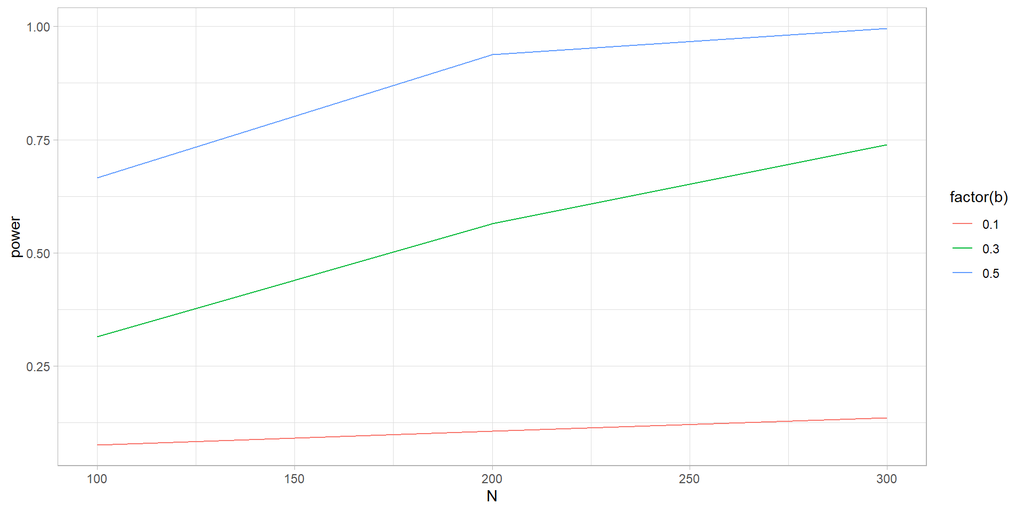

### 7.4.28 Diagnose over multiple moving parts and multiple diagnosands (and ggplot)

```r
design |>

  ## Redesign
  redesign(b = c(0.1, 0.3, 0.5), N = 100, 200, 300) |>

  ## Diagnosis
  diagnose_design() |>

  ## Prep
  tidy() |>

  ## Plot
  ggplot(aes(N, estimate, color = factor(b))) +
  geom_line()+
  facet_wrap(~diagnosand)
```

### 7.4.29 Diagnose over multiple moving parts and multiple diagnosands (and ggplot)

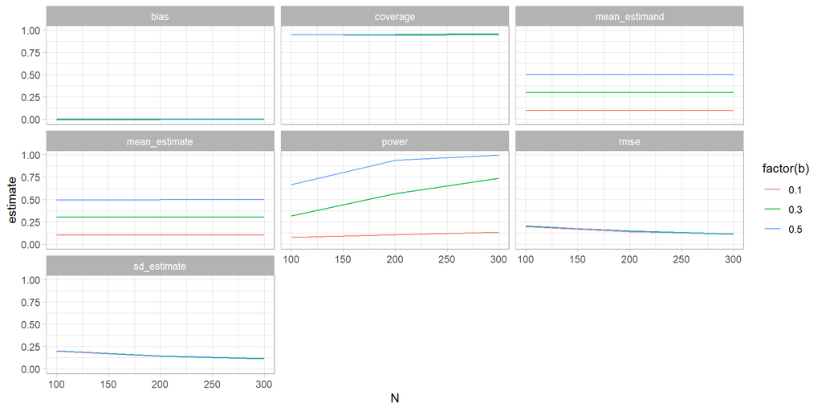

## 7.5 Beyond basics

### 7.5.1 Power tips

coming up:

- power everywhere
- power with bias
- power with the wrong standard errors
- power with uncertainty over effect sizes
- power and multiple comparisons

### 7.5.2 Power depends on all parts of MIDA

We often focus on sample sizes

**But**

Power also depends on

- the model – obviously signal to noise
- the assignments and specifics of sampling strategies
- estimation procedures

### 7.5.3 Power from a lag?

Say we have access to a “pre” measure of outcome `Y_now`; call it `Y_base`. `Y_base` is informative about potential outcomes. We are considering using `Y_now - Y_base` as the outcome instead of `Y_now`.

```r
N <- 100
rho <- .5

design <-
  declare_model(N,
                 Y_base = rnorm(N),
                 Y_Z_0 = 1 + correlate(rnorm, given = Y_base, rho = rho),
                 Y_Z_1 = correlate(rnorm, given = Y_base, rho = rho),
                 Z = complete_ra(N),
                 Y_now = Z*Y_Z_1 + (1-Z)*Y_Z_0,
                 Y_change = Y_now - Y_base) +
  declare_inquiry(ATE = mean(Y_Z_1 - Y_Z_0)) +
  declare_estimator(Y_now ~ Z, label = "level") +
  declare_estimator(Y_change ~ Z, label = "change")+
  declare_estimator(Y_now ~ Z + Y_base, label = "RHS")
```

### 7.5.4 Power from a lag?

```r
design |> redesign(N = c(10, 100, 1000, 10000), rho = c(.1, .5, .9)) |>
  diagnose_design()
```

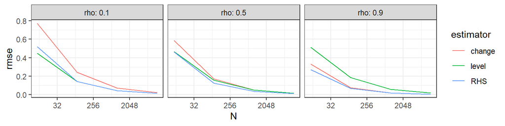

### 7.5.5 Power from a lag?

Punchline:

- if you difference: *the lag has to be sufficiently information to pay its way* (the $\rho = .5$ equivalent between level and change follows from Gerber and Green (2012) equation 4.6)
- The right hand side is your friend, at least for experiments ([Ding and Li (2019)](https://arxiv.org/abs/1903.06286))
- As $N$ grows the stakes fall

### 7.5.6 Power when estimates are biased

```r
bad_design <-

  declare_model(N = 100,
    U = rnorm(N),
    potential_outcomes(Y ~ 0 * X + U, conditions = list(X = 0:1)),
    X = ifelse(U > 0, 1, 0)) +

  declare_measurement(Y = reveal_outcomes(Y ~ X)) +

  declare_inquiry(ate = mean(Y_X_1 - Y_X_0)) +

  declare_estimator(Y ~ X, inquiry = "ate", .method = lm_robust)
```

### 7.5.7 Power when estimates are biased

You can see from the null design that power is great but bias is terrible and coverage is way off.

```r
diagnose_design(bad_design)
```

| Mean Estimate | Bias | SD Estimate | RMSE | Power | Coverage |
| --- | --- | --- | --- | --- | --- |
| 1.59 | 1.59 | 0.12 | 1.60 | 1.00 | 0.00 |
| (0.01) | (0.01) | (0.00) | (0.01) | (0.00) | (0.00) |

Power without unbiasedness corrupts, absolutely

### 7.5.8 Power with a more subtly biased experimental design

```r
another_bad_design <-

  declare_model(
    N = 100,
    female = rep(0:1, N/2),
    U = rnorm(N),
    potential_outcomes(Y ~ female * Z + U)) +

  declare_assignment(
    Z = block_ra(blocks = female, block_prob = c(.1, .5)),
    Y = reveal_outcomes(Y ~ Z)) +

  declare_inquiry(ate = mean(Y_Z_1 - Y_Z_0)) +

  declare_estimator(Y ~ Z + female, inquiry = "ate",
                    .method = lm_robust)
```

```r
  diagnose_design(another_bad_design)
```

### 7.5.9 Power with a more subtly biased experimental design

| Mean Estimate | Bias | SD Estimate | RMSE | Power | Coverage |
| --- | --- | --- | --- | --- | --- |
| 0.76 | 0.26 | 0.24 | 0.35 | 0.84 | 0.85 |
| (0.01) | (0.01) | (0.01) | (0.01) | (0.01) | (0.02) |

### 7.5.10 Power with the wrong standard errors

```r
clustered_design <-
  declare_model(
    cluster = add_level(N = 10, cluster_shock = rnorm(N)),
    individual = add_level(
        N = 100,
        Y_Z_0 = rnorm(N) + cluster_shock,
        Y_Z_1 = rnorm(N) + cluster_shock)) +
  declare_inquiry(ATE = mean(Y_Z_1 - Y_Z_0)) +
  declare_assignment(Z = cluster_ra(clusters = cluster)) +
  declare_measurement(Y = reveal_outcomes(Y ~ Z)) +
  declare_estimator(Y ~ Z, inquiry = "ATE")
```

| Mean Estimate | Bias | SD Estimate | RMSE | Power | Coverage |
| --- | --- | --- | --- | --- | --- |
| -0.00 | -0.00 | 0.64 | 0.64 | 0.79 | 0.20 |
| (0.01) | (0.01) | (0.01) | (0.01) | (0.01) | (0.01) |

What alerts you to a problem?

### 7.5.11 Let’s fix that one

```r
clustered_design_2  <-
  clustered_design |> replace_step(5,
  declare_estimator(Y ~ Z, clusters = cluster))
```

| Mean Estimate | Bias | SD Estimate | RMSE | Power | Coverage |
| --- | --- | --- | --- | --- | --- |
| 0.00 | -0.00 | 0.66 | 0.65 | 0.06 | 0.94 |
| (0.02) | (0.02) | (0.01) | (0.01) | (0.01) | (0.01) |

### 7.5.12 Power when you are not sure about effect sizes (always!)

- you can do power analysis for multiple stipulations
- or you can design with a distribution of effect sizes

```r
design_uncertain <-
  declare_model(N = 1000, b = 1+rnorm(1), Y_Z_1 = rnorm(N), Y_Z_2 = rnorm(N) + b, Y_Z_3 = rnorm(N) + b) +
  declare_assignment(Z = complete_ra(N = N, num_arms = 3, conditions = 1:3)) +
  declare_measurement(Y = reveal_outcomes(Y ~ Z)) +
  declare_inquiry(ate = mean(b)) +
  declare_estimator(Y ~ factor(Z), term = TRUE)

draw_estimands(design_uncertain)
```

```
  inquiry   estimand
1     ate -0.3967765
```

```r
draw_estimands(design_uncertain)
```

```
  inquiry  estimand
1     ate 0.7887188
```

### 7.5.13 Multiple comparisons correction (complex code)

Say I run two tests and want to correct for multiple comparisons.

Two approaches. First, by hand:

```r
b = .2

design_mc <-
  declare_model(N = 1000, Y_Z_1 = rnorm(N), Y_Z_2 = rnorm(N) + b, Y_Z_3 = rnorm(N) + b) +
  declare_assignment(Z = complete_ra(N = N, num_arms = 3, conditions = 1:3)) +
  declare_measurement(Y = reveal_outcomes(Y ~ Z)) +
  declare_inquiry(ate = b) +
  declare_estimator(Y ~ factor(Z), term = TRUE)
```

### 7.5.14 Multiple comparisons correction (complex code)

```r
design_mc |>
  simulate_designs(sims = 1000) |>
  filter(term != "(Intercept)") |>
  group_by(sim_ID) |>
  mutate(p_bonferroni = p.adjust(p = p.value, method = "bonferroni"),
         p_holm = p.adjust(p = p.value, method = "holm"),
         p_fdr = p.adjust(p = p.value, method = "fdr")) |>
  ungroup() |>
  summarize(
    "Power using naive p-values" = mean(p.value <= 0.05),
    "Power using Bonferroni correction" = mean(p_bonferroni <= 0.05),
    "Power using Holm correction" = mean(p_holm <= 0.05),
    "Power using FDR correction" = mean(p_fdr <= 0.05)
    )
```

| Power using naive p-values | Power using Bonferroni correction | Power using Holm correction | Power using FDR correction |
| --- | --- | --- | --- |
| 0.7374 | 0.6318 | 0.6886 | 0.7032 |

### 7.5.15 Multiple comparisons correction (approach 2)

The alternative approach (generally better!) is to design with a custom estimator that includes your corrections.

```r
my_estimator <- function(data)
  lm_robust(Y ~ factor(Z), data = data) |>
  tidy() |>
  filter(term != "(Intercept)") |>
  mutate(p.naive = p.value,
         p.value = p.adjust(p = p.naive, method = "bonferroni"))


design_mc_2 <- design_mc |>
  replace_step(5, declare_estimator(handler = label_estimator(my_estimator)))

run_design(design_mc_2) |>
  select(term, estimate, p.value, p.naive) |> kable()
```

| term | estimate | p.value | p.naive |
| --- | --- | --- | --- |
| factor(Z)2 | 0.1182516 | 0.2502156 | 0.1251078 |
| factor(Z)3 | 0.1057031 | 0.3337476 | 0.1668738 |

### 7.5.16 Multiple comparisons correction (Null model case)

Lets try same thing for a null model (using `redesign(design_mc_2, b = 0)`)

```r
design_mc_3 <-
  design_mc_2 |>
  redesign(b = 0)

run_design(design_mc_3) |> select(estimate, p.value, p.naive) |> kable(digits = 3)
```

| estimate | p.value | p.naive |
| --- | --- | --- |
| 0.068 | 0.799 | 0.399 |
| 0.144 | 0.151 | 0.076 |

### 7.5.17 Multiple comparisons correction (Null model case)

…and power:

| Mean Estimate | Bias | SD Estimate | RMSE | Power | Coverage |
| --- | --- | --- | --- | --- | --- |
| 0.00 | 0.00 | 0.08 | 0.08 | 0.02 | 0.95 |
| (0.00) | (0.00) | (0.00) | (0.00) | (0.00) | (0.01) |
| -0.00 | -0.00 | 0.08 | 0.08 | 0.02 | 0.96 |
| (0.00) | (0.00) | (0.00) | (0.00) | (0.00) | (0.01) |

bothered?

### 7.5.18 You might try

- Power for an interaction (in a factorial design)
- Power for a binary variable (versus a continuous variable?)
- Power gains from blocked randomization
- Power losses from clustering at different levels
- Controlling the ICC directly? (see book cluster designs section)

### 7.5.19 Big takeaways

- Power is affected not just by sample size, variability and effect size but also by you data and analysis strategies.
- Try to estimate power under multiple scenarios
- Try to use the same code for calculating power as you will use in your ultimate analysis
- Basically the same procedure can be used for any design. If you can declare a design and have a test, you can calculate power
- Your power might be right but misleading. For confidence:
  - Don’t just check power, check bias and coverage also
  - Check power especially *under the null*
- Don’t let a focus on power distract you from more *substantive* diagnosands

# 8 Topics

## 8.1 Noncompliance and the LATE estimand

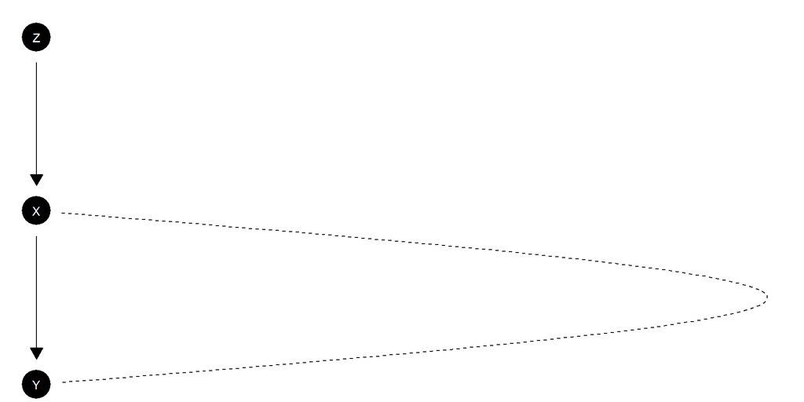

### 8.1.1 Local Average Treatment Effects

Sometimes you give a medicine but only a nonrandom sample of people actually try to use it. Can you still estimate the medicine’s effect?

|  | X=0 | X=1 |
| --- | --- | --- |
| Z=0 | $\overline{y}_{00}$ ($n_{00}$) | $\overline{y}_{01}$ ($n_{01}$) |
| Z=1 | $\overline{y}_{10}$ ($n_{10}$) | $\overline{y}_{11}$ ($n_{11}$) |

Say that people are one of 3 types:

1. $n_a$ “always takers” have $X=1$ no matter what and have average outcome $\overline{y}_a$
2. $n_n$ “never takers” have $X=0$ no matter what with outcome $\overline{y}_n$
3. $n_c$ “compliers have” $X=Z$ and average outcomes $\overline{y}^1_c$ if treated and $\overline{y}^0_c$ if not.

### 8.1.2 Local Average Treatment Effects

Sometimes you give a medicine but only a non random sample of people actually try to use it. Can you still estimate the medicine’s effect?

|  | X=0 | X=1 |
| --- | --- | --- |
| Z=0 | $\overline{y}_{00}$ ($n_{00}$) | $\overline{y}_{01}$ ($n_{01}$) |
| Z=1 | $\overline{y}_{10}$ ($n_{10}$) | $\overline{y}_{11}$ ($n_{11}$) |

We can figure something about types:

|  | $X=0$ | $X=1$ |
| --- | --- | --- |
| $Z=0$ | $\frac{\frac{1}{2}n_c}{\frac{1}{2}n_c + \frac{1}{2}n_n} \overline{y}^0_{c}+\frac{\frac{1}{2}n_n}{\frac{1}{2}n_c + \frac{1}{2}n_n} \overline{y}_{n}$ | $\overline{y}_{a}$ |
| $Z=1$ | $\overline{y}_{n}$ | $\frac{\frac{1}{2}n_c}{\frac{1}{2}n_c + \frac{1}{2}n_a} \overline{y}^1_{c}+\frac{\frac{1}{2}n_a}{\frac{1}{2}n_c + \frac{1}{2}n_a} \overline{y}_{a}$ |

### 8.1.3 Local Average Treatment Effects

You give a medicine to 50% but only a non random sample of people actually try to use it. Can you still estimate the medicine’s effect?

|  | $X=0$ | $X=1$ |
| --- | --- | --- |
| $Z=0$ | $\frac{n_c}{n_c + n_n} \overline{y}^0_{c}+\frac{n_n}{n_c + n_n} \overline{y}_n$ | $\overline{y}_{a}$ |
| (n) | ($\frac{1}{2}(n_c + n_n)$) | ($\frac{1}{2}n_a$) |
| $Z=1$ | $\overline{y}_{n}$ | $\frac{n_c}{n_c + n_a} \overline{y}^1_{c}+\frac{n_a}{n_c + n_a} \overline{y}_{a}$ |
| (n) | ($\frac{1}{2}n_n$) | ($\frac{1}{2}(n_a+n_c)$) |

Key insight: the contributions of the $a$s and $n$s are the *same* in the $Z=0$ and $Z=1$ groups so if you difference you are left with the *changes* in the contributions of the $c$s.

### 8.1.4 Local Average Treatment Effects

Average in $Z=0$ group: $\frac{{n_c} \overline{y}^0_{c}+ \left(n_{n}\overline{y}_{n} +{n_a} \overline{y}_a\right)}{n_a+n_c+n_n}$

Average in $Z=1$ group: $\frac{{n_c} \overline{y}^1_{c} + \left(n_{n}\overline{y}_{n} +{n_a} \overline{y}_a \right)}{n_a+n_c+n_n}$

So, the *difference* is the ITT: $({\overline{y}^1_c-\overline{y}^0_c})\frac{n_c}{n}$

Last step:

$$ITT = ({\overline{y}^1_c-\overline{y}^0_c})\frac{n_c}{n}$$

$$\leftrightarrow$$

$$LATE = \frac{ITT}{\frac{n_c}{n}}= \frac{\text{Intent to treat effect}}{\text{First stage effect}}$$

### 8.1.5 The good and the bad of LATE

- You get a well-defined estimate even when there is non-random take-up
- May sometimes be used to assess mediation or knock-on effects
- But:
  - You need assumptions (monotonicity and the exclusion restriction – *where were these used above*?)
  - Your estimate is only for a subpopulation
  - The subpopulation is not chosen by you and is unknown
  - Different encouragements may yield different estimates since they may encourage different subgroups

### 8.1.6 Pearl and Chickering again

With and without an imposition of monotonicity

```r
data("lipids_data")

models <-
  list(unrestricted =  make_model("Z -> X -> Y; X <-> Y"),
       restricted =  make_model("Z -> X -> Y; X <-> Y") |>
         set_restrictions("X[Z=1] < X[Z=0]")) |>
  lapply(update_model,  data = lipids_data, refresh = 0)

models |>
  query_model(query = list(CATE = "Y[X=1] - Y[X=0]",
                           Nonmonotonic = "X[Z=1] < X[Z=0]"),
              given = list("X[Z=1] > X[Z=0]", TRUE),
              using = "posteriors")
```

### 8.1.7 Pearl and Chickering again

With and without an imposition of monotonicity:

| model | query | mean | sd |
| --- | --- | --- | --- |
| unrestricted | CATE | 0.70 | 0.05 |
| restricted | CATE | 0.71 | 0.05 |
| unrestricted | Nonmonotonic | 0.01 | 0.01 |
| restricted | Nonmonotonic | 0.00 | 0.00 |

In one case we *assume* monotonicity, in the other we **update** on it (easy in this case because of the empirically verifiable nature of one sided non compliance)

## 8.2 Survey experiments

- Survey experiments are used to *measure* things: nothing (except answers) should be *changed*!
- If the experiment in the survey is changing things then it is a field experiment in a survey, not a survey experiment

### 8.2.1 The list experiment: Motivation

- Multiple survey experimental designs have been generated to make it easier for subjects to answer **sensitive questions**
- The key idea is to use inference rather than measurement.
- Subjects are placed in different conditions and the conditions *affect* the **answers** that are given in such a way that you can infer some underlying quantity of interest

### 8.2.2 The list experiment: Motivation

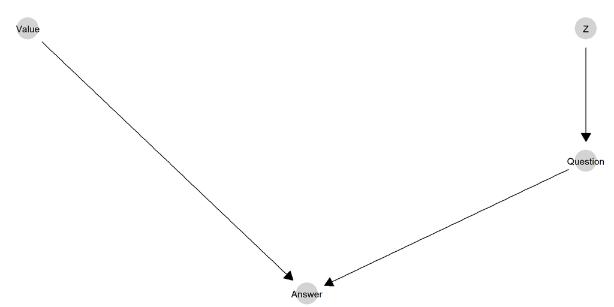

This is an obvious DAG but the main point is to be clear that the *Value* is the quantity of interest and the value is not affected by the treatment, *Z*.

### 8.2.3 The list experiment: Motivation

The list experiment supposes that:

1. Subjects do not want to give a direct answer to a question
2. They nevertheless are willing to truthfully answer an indirect question

**In other words**: sensitivities notwithstanding, *they are happy for the researcher to make correct inferences about them or their group*

### 8.2.4 The list experiment: Strategy

- Respondents are given a short list and a long list.
- The long list differs from the short list in having *one extra item*—the sensitive item
- We ask how many items in each list does a respondent agree with:
  - $Y_i(0)$ is the number of elements on a short list that a respondent agrees with
  - $Y_i(1)$ is the number of elements on a long list that a respondent agrees with
  - $Y_i(1) - Y_i(0)$ is an indicator for whether an individual agrees with the sensitive item
  - $\mathbb{E}[Y_i(1) - Y_i(0)]$ is the share of people agreeing with sensitive item

### 8.2.5 The list experiment: Simplified example

How many of these do you agree with:

[output not shown]

[Note: this is obviously not a good list. Why not?]

### 8.2.6 The list experiment: Design

```r
declaration_17.3 <-
  declare_model(
    N = 500,
    control_count = rbinom(N, size = 3, prob = 0.5),
    Y_star = rbinom(N, size = 1, prob = 0.3),
    potential_outcomes(Y_list ~ Y_star * Z + control_count)
  ) +
  declare_inquiry(prevalence_rate = mean(Y_star)) +
  declare_assignment(Z = complete_ra(N)) +
  declare_measurement(Y_list = reveal_outcomes(Y_list ~ Z)) +
  declare_estimator(Y_list ~ Z, .method = difference_in_means,
                    inquiry = "prevalence_rate")

diagnosands <- declare_diagnosands(
  bias = mean(estimate - estimand),
  mean_CI_width = mean(conf.high - conf.low)
)
```

### 8.2.7 Diagnosis

```r
diagnose_design(declaration_17.3, diagnosands = diagnosands)
```

| Design | Inquiry | Bias | Mean CI Width |
| --- | --- | --- | --- |
| declaration_17.3 | prevalence_rate | 0.00 | 0.32 |
|  |  | (0.00) | (0.00) |

### 8.2.8 Tradeoffs: is the question really sensitive?

```r
declaration_17.4 <-
  declare_model(
    N = N,
    U = rnorm(N),
    control_count = rbinom(N, size = 3, prob = 0.5),
    Y_star = rbinom(N, size = 1, prob = 0.3),
    W = case_when(Y_star == 0 ~ 0L,
                  Y_star == 1 ~ rbinom(N, size = 1, prob = proportion_hiding)),
    potential_outcomes(Y_list ~ Y_star * Z + control_count)
  ) +
  declare_inquiry(prevalence_rate = mean(Y_star)) +
  declare_assignment(Z = complete_ra(N)) +
  declare_measurement(Y_list = reveal_outcomes(Y_list ~ Z),
                      Y_direct = Y_star - W) +
  declare_estimator(Y_list ~ Z, inquiry = "prevalence_rate", label = "list") +
  declare_estimator(Y_direct ~ 1, inquiry = "prevalence_rate", label = "direct")
```

### 8.2.9 Diagnosis

```r
declaration_17.4 |>
  redesign(proportion_hiding = seq(from = 0, to = 0.3, by = 0.1),
           N = seq(from = 500, to = 2500, by = 500)) |>
  diagnose_design()
```

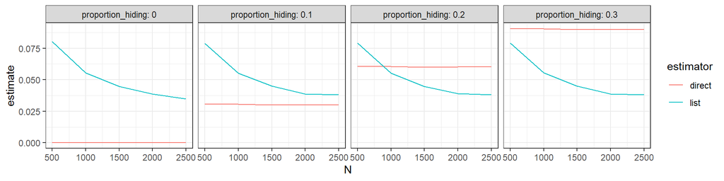

### 8.2.10 Negatively correlated items

- How would estimates be affected if the items selected for the list were *negatively* correlated?
- How would subject protection be affected?

### 8.2.11 Negatively correlated items

```r
rho <- -.8

correlated_lists <-
  declare_model(
    N = 500,
    U = rnorm(N),
    control_1 = rbinom(N, size = 1, prob = 0.5),
    control_2 = correlate(given = control_1, rho = rho, draw_binary, prob = 0.5),
    control_count = control_1 + control_2,
    Y_star = rbinom(N, size = 1, prob = 0.3),
    potential_outcomes(Y_list ~ Y_star * Z + control_count)
  ) +
  declare_inquiry(prevalence_rate = mean(Y_star)) +
  declare_assignment(Z = complete_ra(N)) +
  declare_measurement(Y_list = reveal_outcomes(Y_list ~ Z)) +
  declare_estimator(Y_list ~ Z)
```

### 8.2.12 Negatively correlated items

```r
draw_data(correlated_lists) |> ggplot(aes(control_count)) +
  geom_histogram() + theme_bw()
```

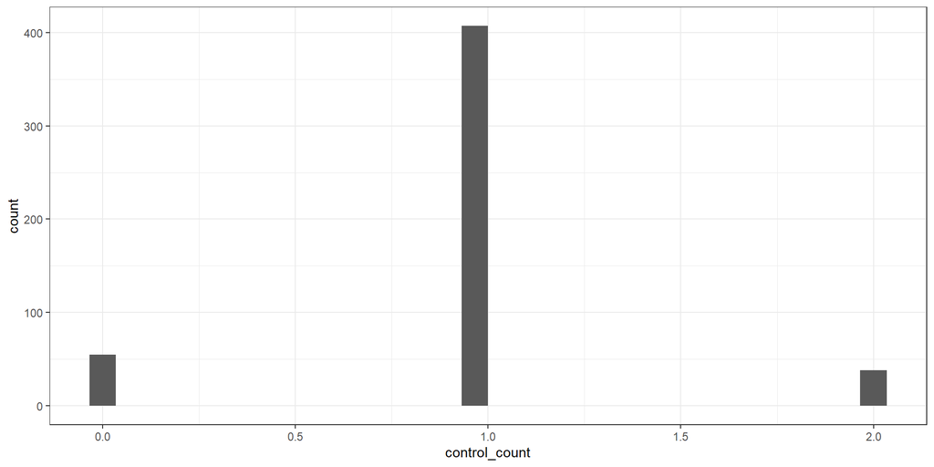

### 8.2.13 Negatively correlated items

```r
correlated_lists |> redesign(rho = c(-.8, 0, .8)) |> diagnose_design()
```

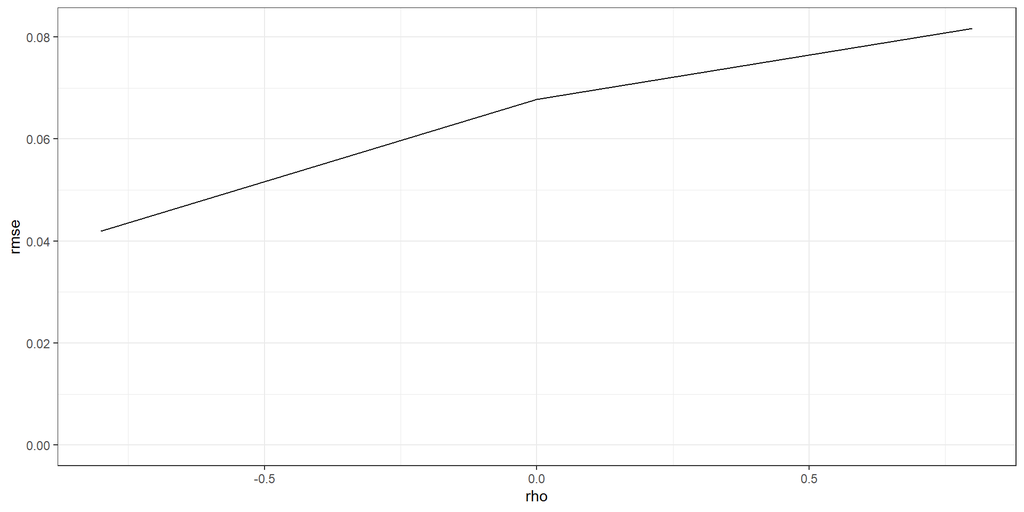

- These trade-off against each other: the more accuracy you have the less protection you have

### 8.2.14 Individual or group effects?

- This is typically used to estimate average *levels*
- However you *can* use it in the obvious way to get average levels for groups: this is equivalent to calculating group level heterogeneous effects
- Extending the idea you can even get *individual level* estimates: for instance you might use causal forests
- You can also use this to estimate the *effect* of an experimental treatment on an item that’s measured using a list, without requiring individual level estimates:

$$Y_i = \beta_0 + \beta_1Z_i + \beta_2Long_i + \beta_3Z_iLong_i$$

### 8.2.15 Hiders and liars

- Note that here we looked at “hiders” – people not answering the direct question truthfully
- See Li (2019) on bounds when the “no liars” assumption is threatened — this is about whether people respond truthfully to the list experimental question

## 8.3 Mediation

### 8.3.1 The problem of unidentified mediators

- Consider a causal system like the below.
- The effect of X on M1 and M2 can be measured in the usual way.
- But unfortunately, if there are multiple mediators, the effect of M1 (or M2) on Y is not identified.
- The ‘exclusion restriction’ is obviously violated when there are multiple mediators (unless you can account for them all).

### 8.3.2 The problem of unidentified mediators

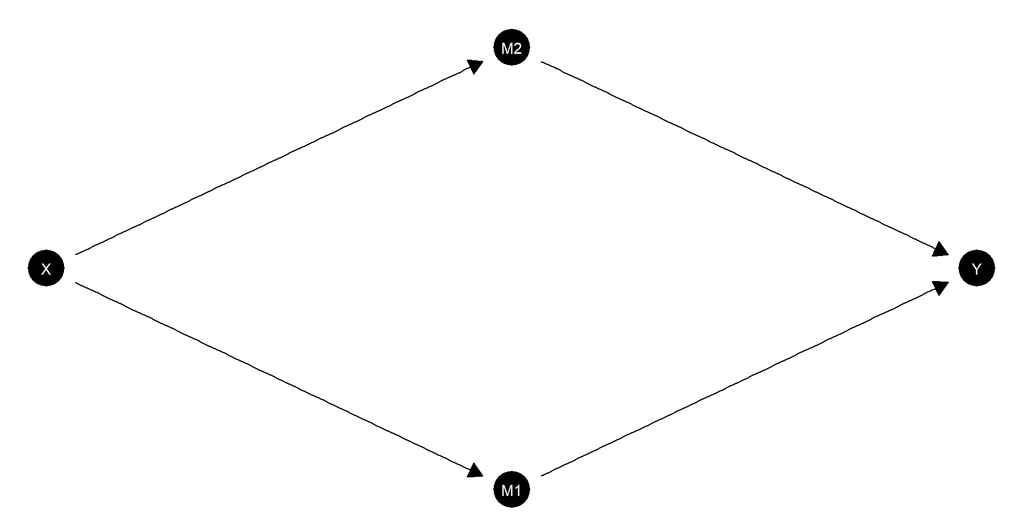

Which effects are identified by the random assignment of $X$?

### 8.3.3 The problem of unidentified mediators

An obvious approach is to first examine the (average) effect of X on M1 and then use another manipulation to examine the (average) effect of M1 on Y.

- But **both of these average effects may be positive (for example) even if there is no effect of X on Y through M1**.

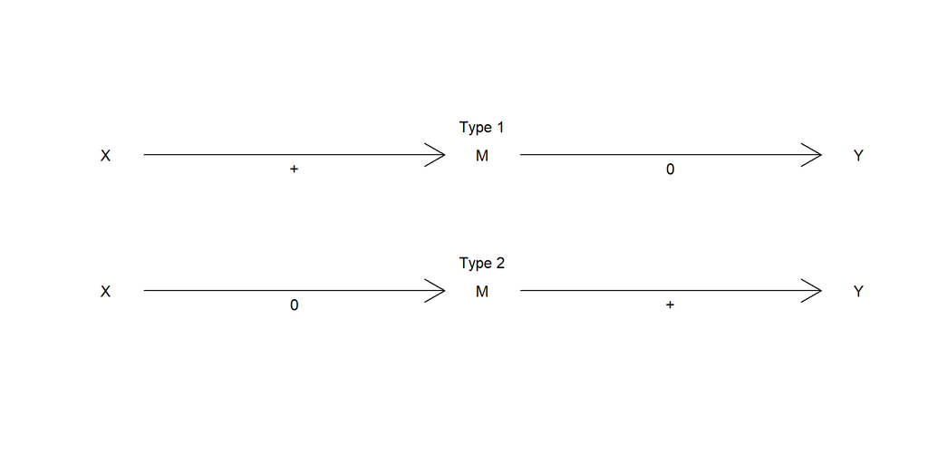

### 8.3.4 The problem of unidentified mediators

An obvious approach is to first examine the (average) effect of X on M1 and then use another manipulation to examine the (average) effect of M1 on Y.

- Similarly **both of these average effects may be zero even if X affects on Y through M1 for every unit!**

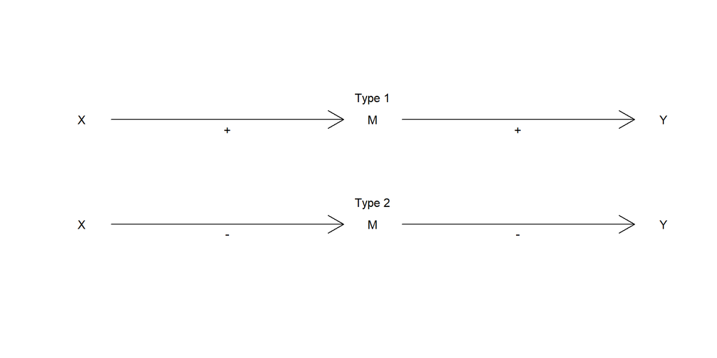

### 8.3.5 The problem of unidentified mediators

Both instances of unobserved confounding between $M$ and $Y$:

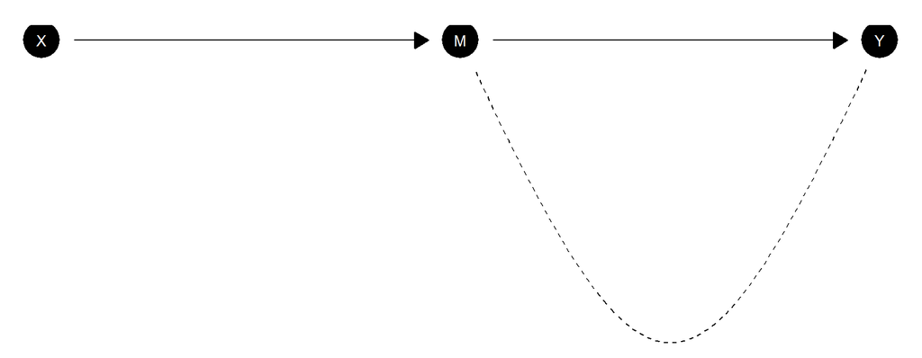

### 8.3.6 The problem of unidentified mediators

Both instances of unobserved confounding between $M$ and $Y$:

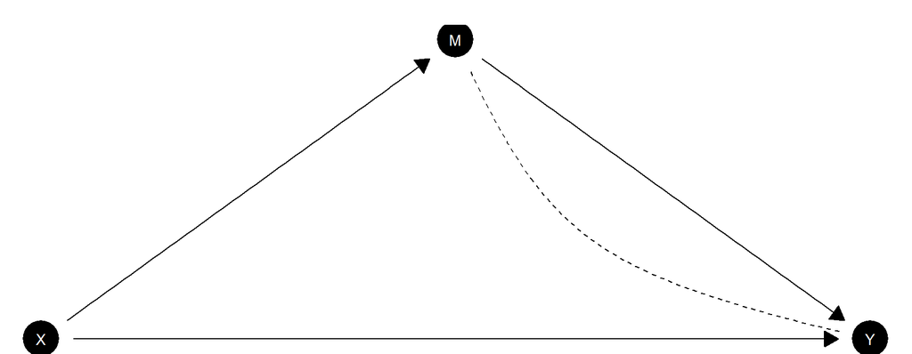

### 8.3.7 The problem of unidentified mediators

- Another somewhat obvious approach is to see how the effect of $X$ on $Y$ in a regression is reduced when you control for $M$.
- If the effect of $X$ on $Y$ passes through $M$ then surely there should be no effect of $X$ on $Y$ after you control for $M$.
- This common strategy associated with Baron and Kenny (1986) is also not guaranteed to produce reliable results. See for instance Green, Ha, and Bullock (2010)

### 8.3.8 Baron Kenny issues

```r
df <- fabricate(N = 1000,
                U = rbinom(N, 1, .5),     X = rbinom(N, 1, .5),
                M = ifelse(U==1, X, 1-X), Y = ifelse(U==1, M, 1-M))

list(lm(Y ~ X, data = df),
     lm(Y ~ X + M, data = df)) |> texreg::htmlreg()
```

Statistical models

|  | Model 1 | Model 2 |
| --- | --- | --- |
| (Intercept) | 0.00*** | 0.00*** |
|  | (0.00) | (0.00) |
| X | 1.00*** | 1.00*** |
|  | (0.00) | (0.00) |
| M |  | 0.00 |
|  |  | (0.00) |
| R<sup>2</sup> | 1.00 | 1.00 |
| Adj. R<sup>2</sup> | 1.00 | 1.00 |
| Num. obs. | 1000 | 1000 |

***p < 0.001; **p < 0.01; *p < 0.05

### 8.3.9 The problem of unidentified mediators

- See [Imai](http://imai.princeton.edu/projects/mechanisms.html) on better ways to think about this problem and designs to address it.

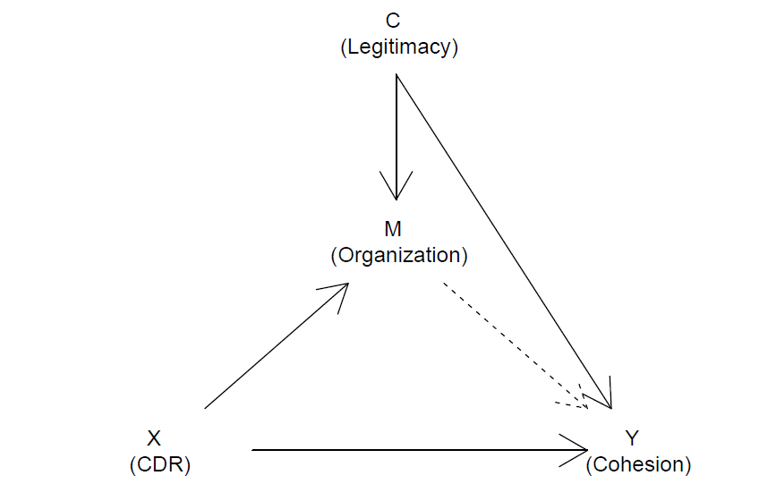

### 8.3.10 The problem of unidentified mediators: Quantities

- Using potential outcomeswe can describe a **mediation effect** as (see Imai et al):
  $$\delta_i(t) = Y_i(t, M_i(1)) - Y_i(t, M_i(0)) \textbf{ for } t = 0,1$$
- The **direct effect** is:
  $$\psi_i(t) = Y_i(1, M_i(t)) - Y_i(0, M_i(t)) \textbf{ for } t = 0,1$$
- This is a **decomposition**, since:
  $$Y_i(1, M_i(1)) - Y_1(0, M_i(0)) = \frac{1}{2}(\delta_i(1) + \delta_i(0) + \psi_i(1) + \psi_i(0))$$
- If there are no interaction effects—ie $\delta_i(1) = \delta_i(0), \psi_i(1) = \psi_i(0)$, then
  $$Y_i(1, M_i(1)) - Y_1(0, M_i(0)) = \delta_i + \psi_i$$

### 8.3.11 The problem of unidentified mediators: Solutions?

The bad news is that although a single experiment might identify the total effect, it can not identify these elements of the direct effect.

So:

- Check **formal requirement** for identification under single experiment design (“sequential ignorability”—that, conditional on actual treatment, it is as if the value of the mediation variable is randomly assigned relative to potential outcomes). But this is strong (and in fact unverifiable) and if it does not hold, bounds on effects always include zero (Imai et al)
- Consider sensitivity analyses

### 8.3.12 **Implicit mediation**

You can use **interactions** with covariates **if you are willing to make assumptions on no heterogeneity of direct treatment effects** over covariates.

eg you think that money makes people get to work faster because they can buy better cars; you look at the marginal effect of more money on time to work for people with and without cars and find it higher for the latter.

This might imply mediation through transport but only if there is no direct effect heterogeneity (eg people with cars are less motivated by money).

### 8.3.13 The problem of unidentified mediators: Solutions?

Weaker assumptions justify **parallel design**

- Group A: $T$ is randomly assigned, $M$ left free.
- Group B: divided into four groups $T\times M$ (requires two more assumptions (1) that the **manipulation** of the mediator only affects outcomes through the mediator (2) **no interaction**, for each unit, $Y(1,m)-Y(0,m) = Y(1,m')-Y(0,m')$.)

**Takeaway**: Understanding mechanisms is harder than you think. Figure out what assumptions fly.

### 8.3.14 In `CausalQueries`

Lets imagine that sequential ignorability does not hold. What are our posteriors on mediation quantities when in fact all effects are mediated, effects are strong, and we have lots of data?

```r
model <- make_model("X -> M ->Y <- X; M <-> Y")

plot(model)
```

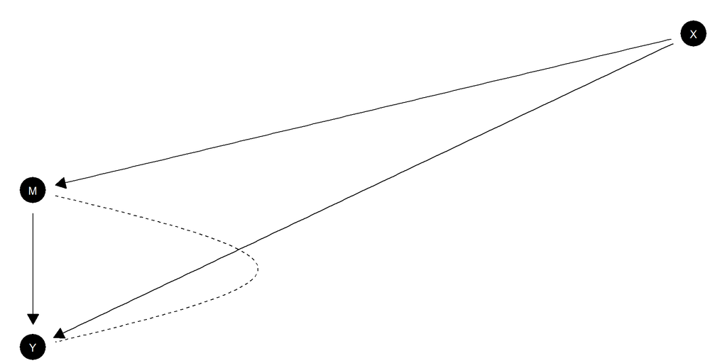

### 8.3.15 In `CausalQueries`

We imagine a true model and consider estimands:

```r
truth <- make_model("X -> M ->Y") |>
  set_parameters(c(.5, .5, .1, 0, .8, .1, .1, 0, .8, .1))

queries  <-
  list(
      indirect = "Y[X = 1, M = M[X=1]] - Y[X = 1, M = M[X=0]]",
      direct = "Y[X = 1, M = M[X=0]] - Y[X = 0, M = M[X=0]]"
      )

truth |> query_model(queries) |> kable()
```

| label | query | given | using | case_level | mean | sd | cred.low | cred.high |
| --- | --- | --- | --- | --- | --- | --- | --- | --- |
| indirect | Y[X = 1, M = M[X=1]] - Y[X = 1, M = M[X=0]] | - | parameters | FALSE | 0.64 | NA | 0.64 | 0.64 |
| direct | Y[X = 1, M = M[X=0]] - Y[X = 0, M = M[X=0]] | - | parameters | FALSE | 0.00 | NA | 0.00 | 0.00 |

### 8.3.16 In `CausalQueries`

```r
model |> update_model(data = truth |> make_data(n = 1000)) |>
  query_distribution(queries = queries, using = "posteriors")
```

[output not shown]

Turns out the data *is* consistent with direct effects only: specifically that whenever $M$ is responsive to $X$, $Y$ is responsive to $X$.

### 8.3.17 In `CausalQueries`

[output not shown]

## 8.4 Spillovers

### 8.4.1 SUTVA violations (Spillovers)

Spillovers can result in the estimation of weaker effects when effects are actually stronger.

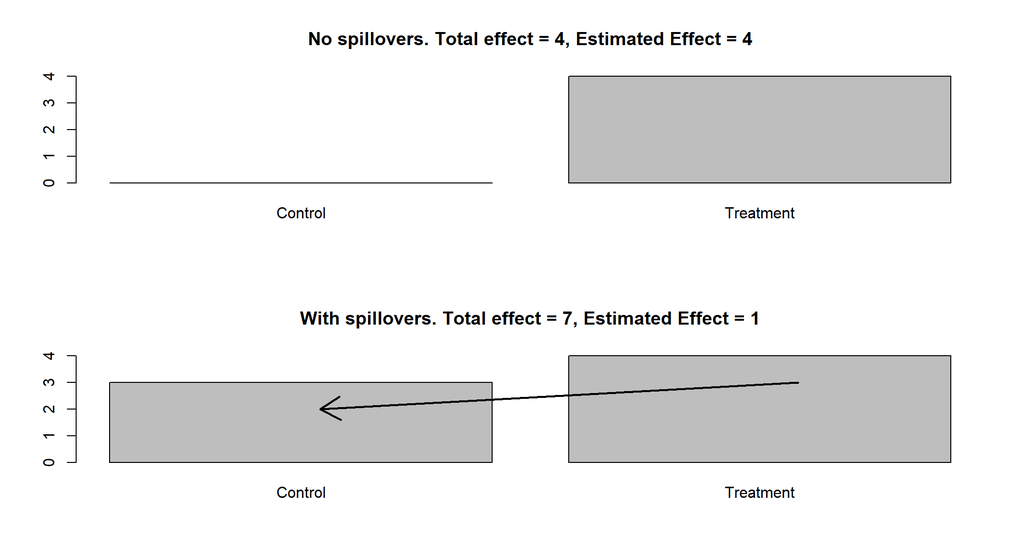

The key problem is that $Y(1)$ and $Y(0)$ are not sufficient to describe potential outcomes

### 8.4.2 SUTVA violations

| Unit | Location | $D_\emptyset$ | $y(D_\emptyset)$ | $D_1$ | $y(D_1)$ | $D_2$ | $y(D_2)$ | $D_3$ | $y(D_3)$ | $D_4$ | $y(D_4)$ |
| --- | --- | --- | --- | --- | --- | --- | --- | --- | --- | --- | --- |
| A | 1 | 0 | 0 | 1 | 3 | 0 | 1 | 0 | 0 | 0 | 0 |
| B | 2 | 0 | 0 | 0 | 3 | 1 | 3 | 0 | 3 | 0 | 0 |
| C | 3 | 0 | 0 | 0 | 0 | 0 | 3 | 1 | 3 | 0 | 3 |
| D | 4 | 0 | 0 | 0 | 0 | 0 | 0 | 0 | 1 | 1 | 3 |

*Table: Potential outcomes for four units for different treatment profiles*. $D_i$ is an allocation and $y_j(D_i)$ is the potential outcome for (row) unit $j$ given (column) $D_i$.

- The key is to think through the structure of spillovers.
- Here immediate neighbors are exposed
- In this case we can **define a direct treatment** (being exposed) and **an indirect treatment** (having a neighbor exposed) and we can work out *the* *propensity* *for each unit of receiving each type of treatment*
- These may be non uniform (here central types are more likely to have teated neighbors); but we can still use the randomization to assess effects

### 8.4.3 SUTVA violations

|  |  |  | **0** |  | **1** |  | **2** |  | **3** |  | **4** |
| --- | --- | --- | --- | --- | --- | --- | --- | --- | --- | --- | --- |
| Unit | Location | $D_\emptyset$ | $y(D_\emptyset)$ | $D_1$ | $y(D_1)$ | $D_2$ | $y(D_2)$ | $D_3$ | $y(D_3)$ | $D_4$ | $y(D_4)$ |
| A | 1 | 0 | 0 | 1 | 3 | 0 | 1 | 0 | 0 | 0 | 0 |
| B | 2 | 0 | 0 | 0 | 3 | 1 | 3 | 0 | 3 | 0 | 0 |
| C | 3 | 0 | 0 | 0 | 0 | 0 | 3 | 1 | 3 | 0 | 3 |
| D | 4 | 0 | 0 | 0 | 0 | 0 | 0 | 0 | 1 | 1 | 3 |
| $\bar{y}_\text{treated}$ |  |  | - |  |  | 3 |  | 3 |  | 3 |  |
| $\bar{y}_\text{untreated}$ |  |  | 0 |  |  | 1 |  | 4/3 |  | 4/3 |  |
| $\bar{y}_\text{neighbors}$ |  |  | - |  |  | 3 |  | 2 |  | 2 |  |
| $\bar{y}_\text{pure control}$ |  |  | 0 |  |  | 0 |  | 0 |  | 0 |  |
| *ATT-direct* |  |  | - |  |  | 3 |  | 3 |  | 3 |  |
| *ATT-indirect* |  |  | - |  |  | 3 |  | 2 |  | 2 |  |

### 8.4.4 Design

```r
dgp <- function(i, Z, G) Z[i]/3 + sum(Z[G == G[i]])^2/5 + rnorm(1)

spillover_design <-

  declare_model(G = add_level(N = 80),
                     j = add_level(N = 3, zeros = 0, ones = 1)) +

  declare_inquiry(direct = mean(sapply(1:240,  # just i treated v no one treated
    function(i) { Z_i <- (1:240) == i
                  dgp(i, Z_i, G) - dgp(i, zeros, G)}))) +

  declare_inquiry(indirect = mean(sapply(1:240,
    function(i) { Z_i <- (1:240) == i           # all but i treated v no one treated
                  dgp(i, ones - Z_i, G) - dgp(i, zeros, G)}))) +

  declare_assignment(Z = complete_ra(N)) +

  declare_measurement(
    neighbors_treated = sapply(1:N, function(i) sum(Z[-i][G[-i] == G[i]])),
    one_neighbor  = as.numeric(neighbors_treated == 1),
    two_neighbors = as.numeric(neighbors_treated == 2),
    Y = sapply(1:N, function(i) dgp(i, Z, G))
  ) +

  declare_estimator(Y ~ Z,
                    inquiry = "direct",
                    model = lm_robust,
                    label = "naive") +

  declare_estimator(Y ~ Z * one_neighbor + Z * two_neighbors,
                    term = c("Z", "two_neighbors"),
                    inquiry = c("direct", "indirect"),
                    label = "saturated",
                    model = lm_robust)
```

### 8.4.5 Spillovers: direct and indirect treatments

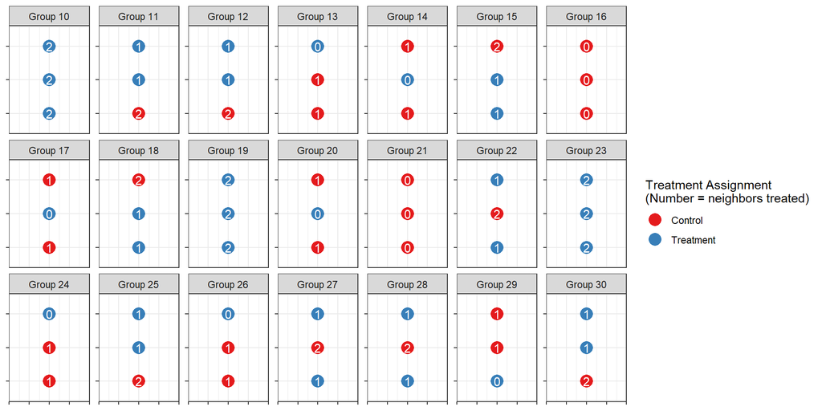

### 8.4.6 Spillovers: Simulated estimates

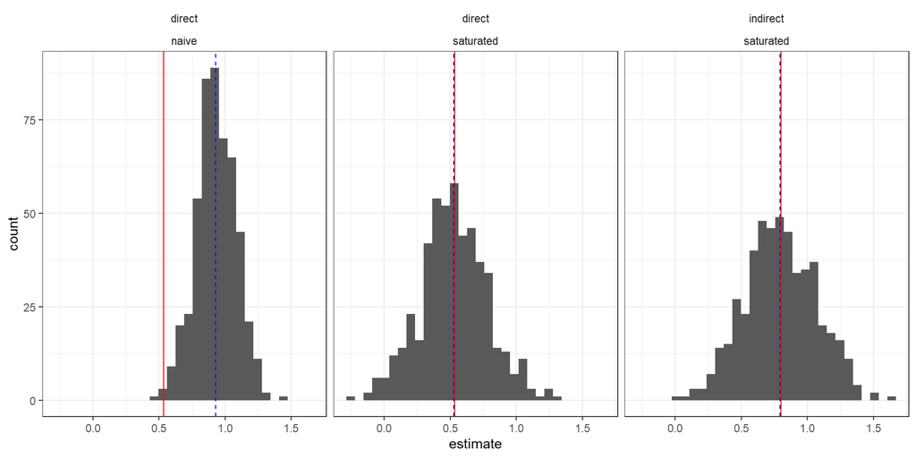

### 8.4.7 Spillovers: Opportunities and Warnings

You can in principle:

- debias estimates
- learn about interesting processes
- optimize design parameters

But to estimate effects you still need *some* SUTVA like assumption.

### 8.4.8 Spillovers: Opportunities and Warnings

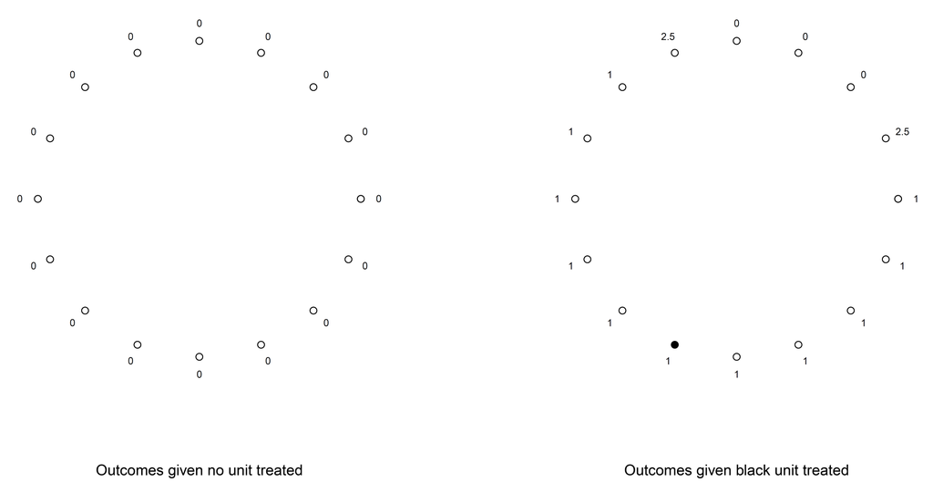

In this example if one compared the outcome between treated units and all control units that are at least $n$ positions away from a treated unit you will get the wrong answer unless $n \geq 7$.

# 9 References

### 9.0.1 References

Baron, Reuben M, and David A Kenny. 1986. “The Moderator–Mediator Variable Distinction in Social Psychological Research: Conceptual, Strategic, and Statistical Considerations.” *Journal of Personality and Social Psychology* 51 (6): 1173.

Choi, Donghyun Danny, Mathias Poertner, and Nicholas Sambanis. 2023. “The Hijab Penalty: Feminist Backlash to Muslim Immigrants.” *American Journal of Political Science* 67 (2): 291–306.

Deaton, Angus, and Nancy Cartwright. 2018. “Understanding and Misunderstanding Randomized Controlled Trials.” *Social Science & Medicine* 210: 2–21.

Ding, Peng, and Fan Li. 2019. “A Bracketing Relationship Between Difference-in-Differences and Lagged-Dependent-Variable Adjustment.” *Political Analysis* 27 (4): 605–15.

Freedman, David A. 2008. “On Regression Adjustments to Experimental Data.” *Advances in Applied Mathematics* 40 (2): 180–93.

Gerber, Alan S, and Donald P Green. 2012. *Field Experiments: Design, Analysis, and Interpretation*. Norton.

Green, Donald P, Shang E Ha, and John G Bullock. 2010. “Enough Already about ‘Black Box’ Experiments: Studying Mediation Is More Difficult Than Most Scholars Suppose.” *The Annals of the American Academy of Political and Social Science* 628 (1): 200–208.

Hall, Ned. 2004. “Two Concepts of Causation.” *Causation and Counterfactuals*, 225–76.

Halpern, Joseph Y. 2016. *Actual Causality*. MIT Press.

Holland, Paul W. 1986. “Statistics and Causal Inference.” *Journal of the American Statistical Association* 81 (396): 945–60.

Imbens, Guido W, and Donald B Rubin. 2015. *Causal Inference in Statistics, Social, and Biomedical Sciences*. Cambridge University Press.

Li, Yimeng. 2019. “Relaxing the No Liars Assumption in List Experiment Analyses.” *Political Analysis* 27 (4): 540–55.

Muralidharan, Karthik, Mauricio Romero, and Kaspar Wüthrich. 2023. “Factorial Designs, Model Selection, and (Incorrect) Inference in Randomized Experiments.” *Review of Economics and Statistics*, 1–44.

Pearl, Judea. 2009. *Causality*. Cambridge university press.

Pearl, Judea, and Dana Mackenzie. 2018. *The Book of Why: The New Science of Cause and Effect*. Basic books.

Pearl, Judea, and Azaria Paz. 1985. *Graphoids: A Graph-Based Logic for Reasoning about Relevance Relations*. University of California (Los Angeles). Computer Science Department.

Robins, James M, Miguel Angel Hernan, and Babette Brumback. 2000. “Marginal Structural Models and Causal Inference in Epidemiology.” LWW.

Samii, Cyrus, and P M Aronow. 2012. “On Equivalencies Between Design-Based and Regression-Based Variance Estimators for Randomized Experiments.” *Statistics & Probability Letters* 82 (2): 365–70.

Shpitser, Ilya, Tyler VanderWeele, and James M Robins. 2012. “On the Validity of Covariate Adjustment for Estimating Causal Effects.” *arXiv Preprint arXiv:1203.3515*.

Textor, Johannes, Benito van der Zander, Mark S Gilthorpe, Maciej Liśkiewicz, and George TH Ellison. 2016. “Robust Causal Inference Using Directed Acyclic Graphs: The r Package ’Dagitty’.” *International Journal of Epidemiology* 45 (6): 1887–94. https://doi.org/10.1093/ije/dyw341.